# TITANIC SURVIVABILITY

This notebook has been created as an entry to the Titanic Machine Learning competition. The best public score achieved was **0.775**.

This has been created by:

- Robin Jonker, 1827572
- Tristan de Groot, 1355583
- Van Niekerk Ferreira, 1834038
- Tristan Lilford, 1843691
- Tristan Basel, 1862166
- Jesse Iyuke, 1606965

The **link to the Kaggle** submission/user can be found [here](https://www.kaggle.com/tristandegroot/competitions?tab=active) or the url can be copied: https://www.kaggle.com/tristandegroot/competitions?tab=active

# APPROACH

We will break up our approach to this challenge into the following sections:

| Section | Title | Description |
| --- | --- | --- |
| 1 | Introduction | Discussion on the competition and our approach |
| 2 | Import Libraries | Import of necessary libraries |
| 3 | Import Data and Brief Analysis | Import the training and test data. Describe the types of data expected. |
| 4 | Data Analyis | Light Data Analysis, Categorical Analysis and Numerical Analysis |
| 5 | Feature Engineering & Data Preprocessing | Creation of different features and preprocessing of data to account for occurances such as NULL values |
| 6 | Model Building | 9 different ML models are built and compared |
| 7 | Model Tuning | Logistic regression, random forest and kNN models are fine tuned using a GridSearch and compared for the best performing feature engineering |
| 8 | Model Execution | Run on the test data and set into form for submission to Kaggle |
| 9 | Summary of Division of work | Description of each group members contribution to the project |
| 10 | Analysis of submissions | Table of some of our submission scores and the description of the method used in each of those submissions. Snapshots of the submission log from Kaggle and the leaderboard position from our best submi… |
| 11 | References | Resources and other notebooks used as inspiration for Approach |

- 1. Introduction
- 2. Import Libraries
- 3. Import Data and Brief Analysis
  - 3.1 Importing the Training and Test Data
  - 3.2 Data Dictionary
  - 3.3 Raw Data Check
- 4. Data Analysis
  - 4.1 Light Data Analysis
  - 4.2 Numerical Data Analysis
  - 4.3 Categorical Data Analysis
- 5. Feature Engineering & DataPreprocessing
- 6. Model Building
  - 6.1 Logistic Regression
  - 6.2 Support Vector Machines
  - 6.3 k-nearest Neighbours (kNN)
  - 6.4 Gaussian Naive Bayes
  - 6.5 Perception
  - 6.6 Linear SVC
  - 6.7 Stochastic Gradient Descent
  - 6.8 Decision Tree
  - 6.9 Random Forest
  - 6.10 Model Accuracy
- 7. Model Tuning
- 8. Model Submission
- 9. Summary of division of work
- 10. Analysis of Submissions
- 11. References

# 1 INTRODUCTION

### Titanic Competition

This notebook details our approach to the Titanic-Machine Learning Disaster Competition. This competition requires us to predict which passengers survived the Titanic disaster using machine learning. For more on this see the [competition page](https://www.kaggle.com/competitions/titanic/overview).

We are provided the following:

- Training Data: This is what we will train our model on
- Test Data: This is what we will test our model on to determine surviveability

### Our Approach

Things to look at

- develop an understanding of the nature of data
- analyse the data through histograms
- analyse the categorical data through value counts
- Decide whether or not to include different sets of missing data. Does the missing data provide an important aspect which should be included or should this data be excluded to prevent the skewing of the data?
- Check the correlation between metrics
- seek common themes -> wealth/location/gender etc
- feature engineering
- preprocess data together or use a transformer
- Check the scaling of the data
- Model Baseline
- Model comparison with CV

# 2 IMPORT LIBRARIES

```python
# Remove warnings
import warnings
warnings.filterwarnings('ignore')

# Data wrangling
import pandas as pd
import numpy as np

# Data visualisation
import seaborn as sns
import matplotlib.pyplot as plt
from collections import Counter

# Data preprocessing
from sklearn import preprocessing

# ML models
from sklearn.model_selection import train_test_split
from sklearn.linear_model import LogisticRegression, Perceptron, SGDClassifier
from sklearn.svm import SVC, LinearSVC
from sklearn.ensemble import RandomForestClassifier
from sklearn.neighbors import KNeighborsClassifier
from sklearn.naive_bayes import GaussianNB
from sklearn.tree import DecisionTreeClassifier

# Model accuracy
from sklearn import metrics
from sklearn.metrics import f1_score
from sklearn.metrics import jaccard_score
from sklearn.metrics import mean_squared_error

# Model evaluation
from sklearn.model_selection import cross_val_score

# Hyperparameter tuning
from sklearn.model_selection import GridSearchCV

# Ensembling
from xgboost import XGBClassifier
from sklearn.ensemble import VotingClassifier
from sklearn.ensemble import BaggingClassifier
```

# 3 IMPORT DATA & BRIEF ANALYSIS

### 3.1 Import the training, test and gender submission data

```python
# Import Training Data and set as Variables so that the data can be assessed
training = pd.read_csv('train.csv')
test = pd.read_csv('test.csv')
ss = pd.read_csv('gender_submission.csv')

# Set Data
training['train_test'] = 1
test['train_test'] = 0
test['Survived'] = np.NaN
all_data = pd.concat([training,test])
test_ids = test['PassengerId']

%matplotlib inline
all_data.columns
```

```
Index(['PassengerId', 'Survived', 'Pclass', 'Name', 'Sex', 'Age', 'SibSp',
       'Parch', 'Ticket', 'Fare', 'Cabin', 'Embarked', 'train_test'],
      dtype='object')
```

### 3.2 Brief Analysis of data types / Data dictionary

The data which must be assessed has different categories and features as described by the Titanic competition page which can be accessed at data. These categories and notable features are described below:

| Variable | Definition | Key |
| --- | --- | --- |
| survival | Survival | 0 = No, 1 = Yes |
| pclass | Ticket class | 1 = 1st, 2 = 2nd, 3 = 3rd |
| sex | Sex |  |
| Age | Age in years |  |
| sibsp | # of siblings / spouses aboard the Titanic |  |
| parch | # of parents / children aboard the Titanic |  |
| ticket | Ticket number |  |
| fare | Passenger fare |  |
| cabin | Cabin number |  |
| embarked | Port of Embarkation | C = Cherbourg, Q = Queenstown, S = Southampton |

A close insepction of the different types of variables:

- pclass: A proxy for socio-economic status (SES)
  - 1st = Upper
  - 2nd = Middle
  - 3rd = Lower
- age: Age is fractional if less than 1. If the age is estimated, is it in the form of xx.5
- sibsp: The dataset defines family relations in this way...
  - Sibling = brother, sister, stepbrother, stepsister
  - Spouse = husband, wife (mistresses and fiancés were ignored)
- parch: The dataset defines family relations in this way...
- Parent = mother, father
- Child = daughter, son, stepdaughter, stepson
  - Some children travelled only with a nanny, therefore parch=0 for them

### 3.3 Raw Data Check

```python
# quick way to separate numeric columns
training.describe().columns
```

```
Index(['PassengerId', 'Survived', 'Pclass', 'Age', 'SibSp', 'Parch', 'Fare',
       'train_test'],
      dtype='object')
```

```python
training.head()
```

|  | PassengerId | Survived | Pclass | Name | Sex | Age | SibSp | Parch | Ticket | Fare | Cabin | Embarked | train_test |
| --- | --- | --- | --- | --- | --- | --- | --- | --- | --- | --- | --- | --- | --- |
| 0 | 1 | 0 | 3 | Braund, Mr. Owen Harris | male | 22.0 | 1 | 0 | A/5 21171 | 7.2500 | NaN | S | 1 |
| 1 | 2 | 1 | 1 | Cumings, Mrs. John Bradley (Florence Briggs Th... | female | 38.0 | 1 | 0 | PC 17599 | 71.2833 | C85 | C | 1 |
| 2 | 3 | 1 | 3 | Heikkinen, Miss. Laina | female | 26.0 | 0 | 0 | STON/O2. 3101282 | 7.9250 | NaN | S | 1 |
| 3 | 4 | 1 | 1 | Futrelle, Mrs. Jacques Heath (Lily May Peel) | female | 35.0 | 1 | 0 | 113803 | 53.1000 | C123 | S | 1 |
| 4 | 5 | 0 | 3 | Allen, Mr. William Henry | male | 35.0 | 0 | 0 | 373450 | 8.0500 | NaN | S | 1 |

```python
test.head()
```

|  | PassengerId | Pclass | Name | Sex | Age | SibSp | Parch | Ticket | Fare | Cabin | Embarked | train_test | Survived |
| --- | --- | --- | --- | --- | --- | --- | --- | --- | --- | --- | --- | --- | --- |
| 0 | 892 | 3 | Kelly, Mr. James | male | 34.5 | 0 | 0 | 330911 | 7.8292 | NaN | Q | 0 | NaN |
| 1 | 893 | 3 | Wilkes, Mrs. James (Ellen Needs) | female | 47.0 | 1 | 0 | 363272 | 7.0000 | NaN | S | 0 | NaN |
| 2 | 894 | 2 | Myles, Mr. Thomas Francis | male | 62.0 | 0 | 0 | 240276 | 9.6875 | NaN | Q | 0 | NaN |
| 3 | 895 | 3 | Wirz, Mr. Albert | male | 27.0 | 0 | 0 | 315154 | 8.6625 | NaN | S | 0 | NaN |
| 4 | 896 | 3 | Hirvonen, Mrs. Alexander (Helga E Lindqvist) | female | 22.0 | 1 | 1 | 3101298 | 12.2875 | NaN | S | 0 | NaN |

```python
ss.head()
```

|  | PassengerId | Survived |
| --- | --- | --- |
| 0 | 892 | 0 |
| 1 | 893 | 1 |
| 2 | 894 | 0 |
| 3 | 895 | 0 |
| 4 | 896 | 1 |

# 4 DATA ANALYSIS

This section will serve to perform the follow functions: 1) Understand the shape of the data (Histograms, box plots, etc.)

2) Data Cleaning

3) Data Exploration

### 4.1 Light Data Analysis

First we will look at the **data types** and the **prevalence of null values** in each of the categories

```python
training.info()
```

```
<class 'pandas.core.frame.DataFrame'>
RangeIndex: 891 entries, 0 to 890
Data columns (total 13 columns):
 #   Column       Non-Null Count  Dtype
---  ------       --------------  -----
 0   PassengerId  891 non-null    int64
 1   Survived     891 non-null    int64
 2   Pclass       891 non-null    int64
 3   Name         891 non-null    object
 4   Sex          891 non-null    object
 5   Age          714 non-null    float64
 6   SibSp        891 non-null    int64
 7   Parch        891 non-null    int64
 8   Ticket       891 non-null    object
 9   Fare         891 non-null    float64
 10  Cabin        204 non-null    object
 11  Embarked     889 non-null    object
 12  train_test   891 non-null    int64
dtypes: float64(2), int64(6), object(5)
memory usage: 90.6+ KB
```

We can sort the data categories by the number of **missing data** values which can be found in each for the **training data**

```python
training.isnull().sum().sort_values(ascending = False)
```

```
Cabin          687
Age            177
Embarked         2
PassengerId      0
Survived         0
Pclass           0
Name             0
Sex              0
SibSp            0
Parch            0
Ticket           0
Fare             0
train_test       0
dtype: int64
```

We can sort the categories by the number of **missing data values** which can be found for each for the **Test data**

```python
test.isnull().sum().sort_values(ascending = False)
```

```
Survived       418
Cabin          327
Age             86
Fare             1
PassengerId      0
Pclass           0
Name             0
Sex              0
SibSp            0
Parch            0
Ticket           0
Embarked         0
train_test       0
dtype: int64
```

**Conclusion:** In the training data there are significant missing values within the Cabin and Age categories. This pattern is replicated in the test data. A missing cabin record could be due to passengers being from a lower socio-economic background and not being able to afford a cabin. The test data has missing values for the survived category, which is the target category we wish to determine.

To better understand the numerical training data, we want to use the describe() method. This will give us an understanding of the **central tendencies** of the **training data.**

```python
training.describe()
```

|  | PassengerId | Survived | Pclass | Age | SibSp | Parch | Fare | train_test |
| --- | --- | --- | --- | --- | --- | --- | --- | --- |
| count | 891.000000 | 891.000000 | 891.000000 | 714.000000 | 891.000000 | 891.000000 | 891.000000 | 891.0 |
| mean | 446.000000 | 0.383838 | 2.308642 | 29.699118 | 0.523008 | 0.381594 | 32.204208 | 1.0 |
| std | 257.353842 | 0.486592 | 0.836071 | 14.526497 | 1.102743 | 0.806057 | 49.693429 | 0.0 |
| min | 1.000000 | 0.000000 | 1.000000 | 0.420000 | 0.000000 | 0.000000 | 0.000000 | 1.0 |
| 25% | 223.500000 | 0.000000 | 2.000000 | 20.125000 | 0.000000 | 0.000000 | 7.910400 | 1.0 |
| 50% | 446.000000 | 0.000000 | 3.000000 | 28.000000 | 0.000000 | 0.000000 | 14.454200 | 1.0 |
| 75% | 668.500000 | 1.000000 | 3.000000 | 38.000000 | 1.000000 | 0.000000 | 31.000000 | 1.0 |
| max | 891.000000 | 1.000000 | 3.000000 | 80.000000 | 8.000000 | 6.000000 | 512.329200 | 1.0 |

To better understand the numerical test data, we want to use the describe() method. This will give us an understanding of the **central tendencies** of the **test data.**

```python
test.describe()
```

|  | PassengerId | Pclass | Age | SibSp | Parch | Fare | train_test | Survived |
| --- | --- | --- | --- | --- | --- | --- | --- | --- |
| count | 418.000000 | 418.000000 | 332.000000 | 418.000000 | 418.000000 | 417.000000 | 418.0 | 0.0 |
| mean | 1100.500000 | 2.265550 | 30.272590 | 0.447368 | 0.392344 | 35.627188 | 0.0 | NaN |
| std | 120.810458 | 0.841838 | 14.181209 | 0.896760 | 0.981429 | 55.907576 | 0.0 | NaN |
| min | 892.000000 | 1.000000 | 0.170000 | 0.000000 | 0.000000 | 0.000000 | 0.0 | NaN |
| 25% | 996.250000 | 1.000000 | 21.000000 | 0.000000 | 0.000000 | 7.895800 | 0.0 | NaN |
| 50% | 1100.500000 | 3.000000 | 27.000000 | 0.000000 | 0.000000 | 14.454200 | 0.0 | NaN |
| 75% | 1204.750000 | 3.000000 | 39.000000 | 1.000000 | 0.000000 | 31.500000 | 0.0 | NaN |
| max | 1309.000000 | 3.000000 | 76.000000 | 8.000000 | 9.000000 | 512.329200 | 0.0 | NaN |

A quick way we can separate the numerical columns is with:

```python
training.describe().columns
```

```
Index(['PassengerId', 'Survived', 'Pclass', 'Age', 'SibSp', 'Parch', 'Fare',
       'train_test'],
      dtype='object')
```

It is also important to understand the **shape** of the test, training and gender submission data

```python
print("Training set shape: ", training.shape)
print("Test set shape: ", test.shape)
print("Gender submission set shape: ", ss.shape)
```

```
Training set shape:  (891, 13)
Test set shape:  (418, 13)
Gender submission set shape:  (418, 2)
```

```python
# Look at numeric and categorical values separately
df_num = training[['Age','SibSp','Parch','Fare']]
df_cat = training[['Survived','Pclass','Sex','Ticket','Cabin','Embarked']]
```

### 4.2 Numerical Data Analysis

The following are the numerical variables which will be analysed in this section:

- Age
- SibSp
- Parch
- Fare

Checking the **distributions** for all the **numeric** variables:

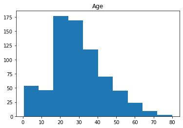

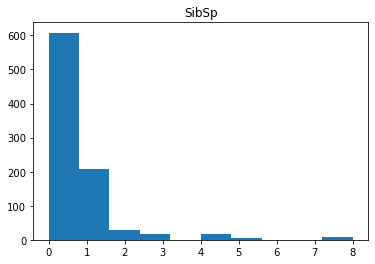

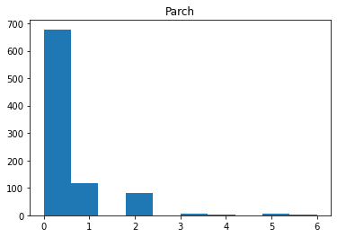

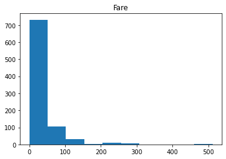

```python
for i in df_num.columns:
    plt.hist((df_num[i]))
    plt.title(i)
    plt.show()
```

Checking the **Outliers** to determine the prevalence of outliers and to decide whether or not to include these outliers or to remove them from the dataset:

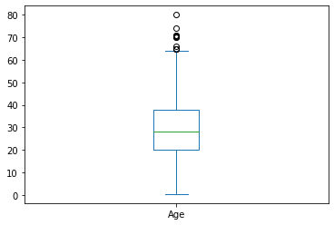

```python
#Box plot to see outliers for Age
df_num['Age'].plot(kind='box')
```

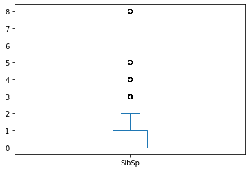

```python
#Box plot to see outliers for SibSp
df_num['SibSp'].plot(kind='box')
```

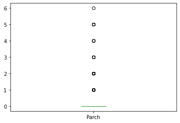

```python
#Box plot to see outliers for Parch
df_num['Parch'].plot(kind='box')
```

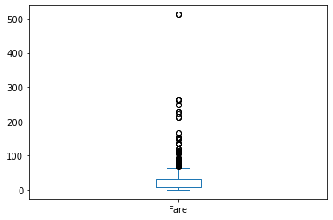

```python
#Box plot to see outliers for Fare
df_num['Fare'].plot(kind='box')
```

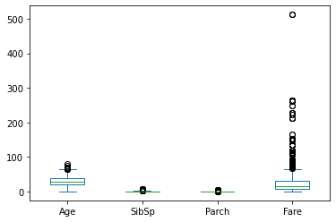

```python
#Box plot to see outliers for Fare
df_num.plot(kind='box')
```

**Detecting and Removing Outliers:**

This **function** will loop through a list of features and detect outliers in each one of those features. In each loop, a data point is deemed an outlier **if it is less** than the **first quartile minus the outlier step** or exceeds third quartile plus the outlier step. The **outlier step** is defined as **1.5 times the interquartile range**. Once the outliers have been determined for one feature, their indices will be stored in a list before proceeding to the next feature and the process repeats until the very last feature is completed. Finally, using the list with outlier indices, we will count the frequencies of the index numbers and return them if their frequency exceeds n times.

```python
def detect_outliers(df, n, features):

    outlier_indices = []
    for col in features:
        Q1 = np.percentile(df[col], 25)
        Q3 = np.percentile(df[col], 75)
        IQR = Q3 - Q1
        outlier_step = 1.5 * IQR
        outlier_list_col = df[(df[col] < Q1 - outlier_step) | (df[col] > Q3 + outlier_step)].index
        outlier_indices.extend(outlier_list_col)
    outlier_indices = Counter(outlier_indices)
    multiple_outliers = list(key for key, value in outlier_indices.items() if value > n)
    return multiple_outliers
# Print out the possible outliers for demonstration
training.loc[detect_outliers(training, 2, ['Age', 'SibSp', 'Parch', 'Fare']), :]
```

|  | PassengerId | Survived | Pclass | Name | Sex | Age | SibSp | Parch | Ticket | Fare | Cabin | Embarked | train_test |
| --- | --- | --- | --- | --- | --- | --- | --- | --- | --- | --- | --- | --- | --- |
| 27 | 28 | 0 | 1 | Fortune, Mr. Charles Alexander | male | 19.0 | 3 | 2 | 19950 | 263.00 | C23 C25 C27 | S | 1 |
| 88 | 89 | 1 | 1 | Fortune, Miss. Mabel Helen | female | 23.0 | 3 | 2 | 19950 | 263.00 | C23 C25 C27 | S | 1 |
| 159 | 160 | 0 | 3 | Sage, Master. Thomas Henry | male | NaN | 8 | 2 | CA. 2343 | 69.55 | NaN | S | 1 |
| 180 | 181 | 0 | 3 | Sage, Miss. Constance Gladys | female | NaN | 8 | 2 | CA. 2343 | 69.55 | NaN | S | 1 |
| 201 | 202 | 0 | 3 | Sage, Mr. Frederick | male | NaN | 8 | 2 | CA. 2343 | 69.55 | NaN | S | 1 |
| 324 | 325 | 0 | 3 | Sage, Mr. George John Jr | male | NaN | 8 | 2 | CA. 2343 | 69.55 | NaN | S | 1 |
| 341 | 342 | 1 | 1 | Fortune, Miss. Alice Elizabeth | female | 24.0 | 3 | 2 | 19950 | 263.00 | C23 C25 C27 | S | 1 |
| 792 | 793 | 0 | 3 | Sage, Miss. Stella Anna | female | NaN | 8 | 2 | CA. 2343 | 69.55 | NaN | S | 1 |
| 846 | 847 | 0 | 3 | Sage, Mr. Douglas Bullen | male | NaN | 8 | 2 | CA. 2343 | 69.55 | NaN | S | 1 |
| 863 | 864 | 0 | 3 | Sage, Miss. Dorothy Edith "Dolly" | female | NaN | 8 | 2 | CA. 2343 | 69.55 | NaN | S | 1 |

For our **first submission** we will not remove any outliers.

**Correlation between numeric variables**

```
          Survived       Age     SibSp     Parch      Fare
Survived  1.000000 -0.077221 -0.035322  0.081629  0.257307
Age      -0.077221  1.000000 -0.308247 -0.189119  0.096067
SibSp    -0.035322 -0.308247  1.000000  0.414838  0.159651
Parch     0.081629 -0.189119  0.414838  1.000000  0.216225
Fare      0.257307  0.096067  0.159651  0.216225  1.000000
```

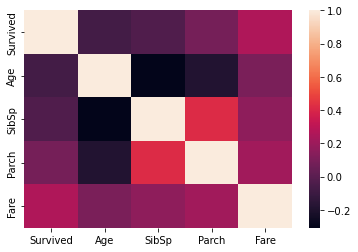

```python
df_num_1 = training[['Survived','Age','SibSp','Parch','Fare']]
print(df_num_1.corr())
sns.heatmap(df_num_1.corr())
```

**Numerical Variable SibSp**

As can be seen below this variable has no null values. The value counts of this column reveal the family composition of each individual on board. Most passengers did not have a spouse or a sibling on board with them. The mean survival by SibSp reveals that those with one/two siblings or spouses on board may be more likely to survive than those who boarded alone. This trend decreased as the number of siblings/spouse aboard increases.

```python
# Null values in SibSp column
training['SibSp'].isnull().sum()
```

```
0
```

```python
# Value counts of the SibSp column
training['SibSp'].value_counts(dropna = False)
```

```
0    608
1    209
2     28
4     18
3     16
8      7
5      5
Name: SibSp, dtype: int64
```

```python
# Mean of survival by SibSp
training[['SibSp', 'Survived']].groupby('SibSp', as_index = False).mean().sort_values(by = 'Survived', ascending = False)
```

|  | SibSp | Survived |
| --- | --- | --- |
| 1 | 1 | 0.535885 |
| 2 | 2 | 0.464286 |
| 0 | 0 | 0.345395 |
| 3 | 3 | 0.250000 |
| 4 | 4 | 0.166667 |
| 5 | 5 | 0.000000 |
| 6 | 8 | 0.000000 |

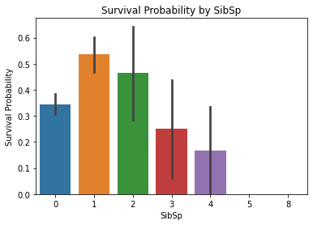

```python
sns.barplot(x = 'SibSp', y ='Survived', data = training)
plt.ylabel('Survival Probability')
plt.title('Survival Probability by SibSp')
```

**Numerical variable: Parch**

The Parch numerical variable has no NULL values. The value counts of this variable reveal that most passengers do not have either a child or parent on board. The mean survival and bar plot indicate come correlation between having a child or parent on board and surviving.

```python
# Null values in Age column
training['Parch'].isnull().sum()
```

```
0
```

```python
# Value counts of the Parch column
training['Parch'].value_counts(dropna = False)
```

```
0    678
1    118
2     80
5      5
3      5
4      4
6      1
Name: Parch, dtype: int64
```

```python
# Mean of survival by Parch
training[['Parch', 'Survived']].groupby('Parch', as_index = False).mean().sort_values(by = 'Survived', ascending = False)
```

|  | Parch | Survived |
| --- | --- | --- |
| 3 | 3 | 0.600000 |
| 1 | 1 | 0.550847 |
| 2 | 2 | 0.500000 |
| 0 | 0 | 0.343658 |
| 5 | 5 | 0.200000 |
| 4 | 4 | 0.000000 |
| 6 | 6 | 0.000000 |

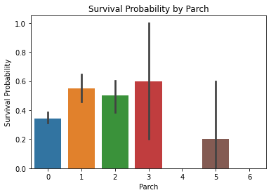

```python
sns.barplot(x = 'Parch', y ='Survived', data = training)
plt.ylabel('Survival Probability')
plt.title('Survival Probability by Parch')
```

**Numerical Variable: Age**

This variable contains 177 NULL values as can be seen below. This needs to be addressed before running on the model. Either these values must be removed from the data, or these values must be set to a specific value (such as the average age of the other passengers). This will be done in the Data preprocessing section.

```python
# Null values in Age column
training['Age'].isnull().sum()
```

```
177
```

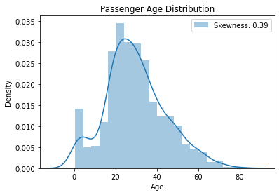

```python
# Passenger age distribution
sns.distplot(training['Age'], label = 'Skewness: %.2f'%(training['Age'].skew()))
plt.legend(loc = 'best')
plt.title('Passenger Age Distribution')
```

```python
# Checking the average age of passenger and those who survived
print(training['Age'].mean())
print(training['Age'][training['Survived'] == 1].mean())
```

```
29.69911764705882
28.343689655172415
```

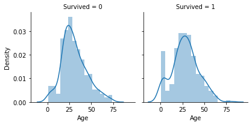

```python
# Age distribution by survival
g = sns.FacetGrid(training, col = 'Survived')
g.map(sns.distplot, 'Age')
```

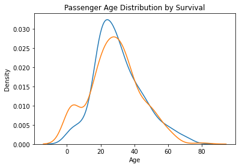

```python
sns.kdeplot(training['Age'][training['Survived'] == 0], label = 'Did not survive')
sns.kdeplot(training['Age'][training['Survived'] == 1], label = 'Survived')
plt.xlabel('Age')
plt.title('Passenger Age Distribution by Survival')
```

**Numerical variable: Fare**

This variable has no NULL values which need to be addressed. The passenger fare distribution reveals that the majority of passengers paid a cheaper Fare. This is likely to correlate to the class ticket of the passengers which will be discussed in the categorical analysis of PClass.

```python
# Null values of Fare column
training['Fare'].isnull().sum()
```

```
0
```

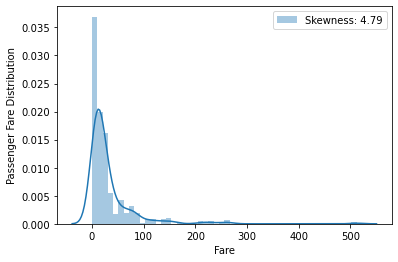

```python
# Passenger fare distribution

sns.distplot(training['Fare'], label = 'Skewness: %.2f'%(training['Fare'].skew()))
plt.legend(loc = 'best')
plt.ylabel('Passenger Fare Distribution')
```

**Survival rates of numerical variables**

```python
pd.pivot_table(training, index = 'Survived', values = ['Age','SibSp','Parch','Fare'])
```

| Survived | Age | Fare | Parch | SibSp |
| --- | --- | --- | --- | --- |
| 0 | 30.626179 | 22.117887 | 0.329690 | 0.553734 |
| 1 | 28.343690 | 48.395408 | 0.464912 | 0.473684 |

**Numerical Analysis Conclusion**

### 4.3 Categorical Data Analysis

The following categorical variables will be anaylsed in this section:

- Survived
- Sex
- Pclass
- Embarked

**Categorical Variable: Survived**

This variable shows that a passengers was more likely to NOT survive than to survive.

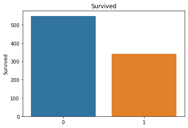

```python
sns.barplot(df_cat['Survived'].value_counts().index, df_cat['Survived'].value_counts()).set_title('Survived')
```

**Categorical variable: Sex**

This variable reveals that there were more male passengers than female passengers. The mean survival by sex and bar plot below indicates that Females were significantly more likely to survive than males.

```python
# Value counts of the sex column
training['Sex'].value_counts(dropna = False)
```

```
male      577
female    314
Name: Sex, dtype: int64
```

```python
# Mean of survival by sex
training[['Sex', 'Survived']].groupby('Sex', as_index = False).mean().sort_values(by = 'Survived', ascending = False)
```

|  | Sex | Survived |
| --- | --- | --- |
| 0 | female | 0.742038 |
| 1 | male | 0.188908 |

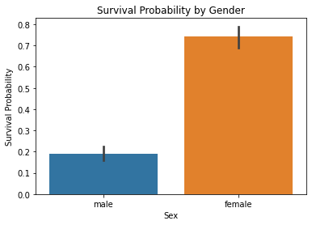

```python
sns.barplot(x = 'Sex', y ='Survived', data = training)
plt.ylabel('Survival Probability')
plt.title('Survival Probability by Gender')
```

**Categrocial Variable: Pclass**

This variable reveals that most passengers were in third class. Survival probability appears to decrease with passenger class as first class passengers may have been prioritised during the evacuation. When analysing survival probability by sex and class, female passengers in 1st class were the most likely to survive and Male passengers in 3rd class were the least likely to survive.

```python
# Value counts of the Pclass column
training['Pclass'].value_counts(dropna = False)
```

```
3    491
1    216
2    184
Name: Pclass, dtype: int64
```

```python
# Mean of survival by passenger class
training[['Pclass', 'Survived']].groupby(['Pclass'], as_index = False).mean().sort_values(by = 'Survived', ascending = False)
```

|  | Pclass | Survived |
| --- | --- | --- |
| 0 | 1 | 0.629630 |
| 1 | 2 | 0.472826 |
| 2 | 3 | 0.242363 |

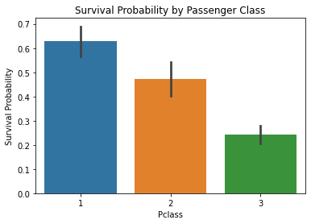

```python
sns.barplot(x = 'Pclass', y ='Survived', data = training)
plt.ylabel('Survival Probability')
plt.title('Survival Probability by Passenger Class')
```

Survival by gender and passenger class

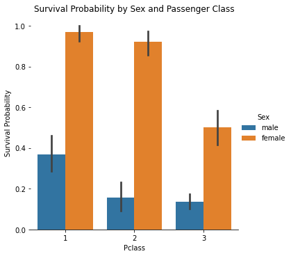

```python
g = sns.factorplot(x = 'Pclass', y = 'Survived', hue = 'Sex', data = training, kind = 'bar')
g.despine(left = True)
plt.ylabel('Survival Probability')
plt.title('Survival Probability by Sex and Passenger Class')
```

**Categorical Variable: Embarked**

This variable has two missing values. If a passenger did not have an Embarked variable, this could perhaps indicate that the passenger might have been a **stowaway** on board the Titanic. In the feature engineering section these values could be excluded or included as their own Embark location.

```python
# Value counts of the Embarked column
training['Embarked'].value_counts(dropna = False)
```

```
S      644
C      168
Q       77
NaN      2
Name: Embarked, dtype: int64
```

```python
# Mean of survival by point of embarkation
training[['Embarked', 'Survived']].groupby(['Embarked'], as_index = False).mean().sort_values(by = 'Survived', ascending = False)
```

|  | Embarked | Survived |
| --- | --- | --- |
| 0 | C | 0.553571 |
| 1 | Q | 0.389610 |
| 2 | S | 0.336957 |

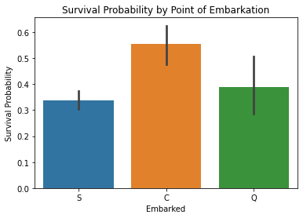

```python
sns.barplot(x = 'Embarked', y ='Survived', data = training)
plt.ylabel('Survival Probability')
plt.title('Survival Probability by Point of Embarkation')
```

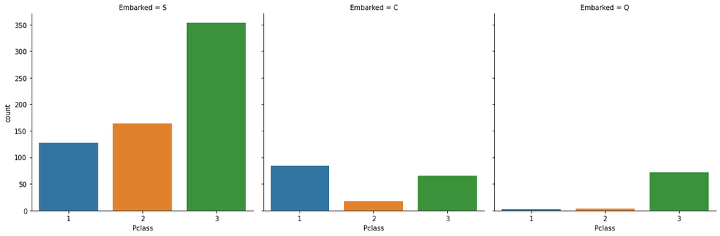

```python
sns.factorplot('Pclass', col = 'Embarked', data = training, kind = 'count')
```

**Survival Rate Accross all Categorical Variables**

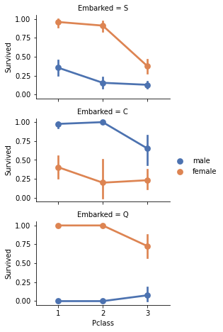

```python
grid = sns.FacetGrid(training, row = 'Embarked', size = 2.2, aspect = 1.6)
grid.map(sns.pointplot, 'Pclass', 'Survived', 'Sex', palette = 'deep')
grid.add_legend()
```

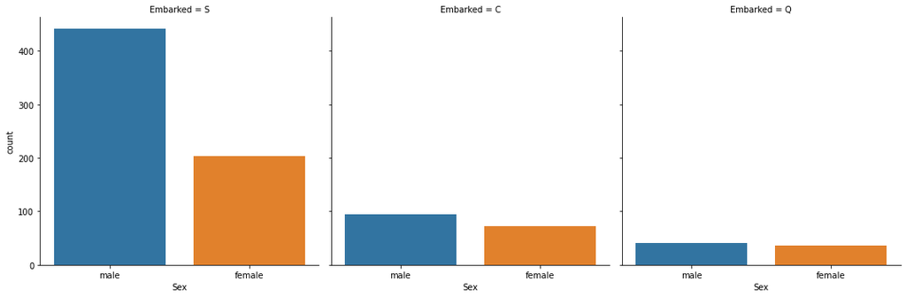

```python
sns.factorplot('Sex', col = 'Embarked', data = training, kind = 'count')
```

**Due to Grid plot above, investigation on gender at each location**

Unlike locations S and Q, more males survive from those embarking at location C, the reason is currently undetermined and investigation with other instances is needed. The plots also give confirmation that the survival rate decreases with class.

```python
# Comparing survival and each of these categorical variables
print(pd.pivot_table(training, index = 'Survived', columns = 'Pclass', values = 'Ticket', aggfunc = 'count'))
print()

print(pd.pivot_table(training, index = 'Survived', columns = 'Embarked', values = 'Ticket', aggfunc = 'count'))
print()

print(pd.pivot_table(training, index = 'Survived', columns = 'Sex', values = 'Ticket', aggfunc = 'count'))
print()
```

```
Pclass      1   2    3
Survived
0          80  97  372
1         136  87  119

Embarked   C   Q    S
Survived
0         75  47  427
1         93  30  217

Sex       female  male
Survived
0             81   468
1            233   109
```

**Categorical Variables Conclusion**

# 5 FEATURE ENGINEERING & DATA PREPROCESSING

## 5.1 Converting relevant categorical columns into numerical columns

Converting the 2 NaN rows of **Embarked** to match the most common option and converted **Embarked** and **Sex** into numerical values

```python
mode = training['Embarked'].dropna().mode()[0]
training['Embarked'].fillna(mode, inplace = True)
```

```python
training['Sex'] = training['Sex'].map({'male': 0, 'female': 1})
test['Sex'] = test['Sex'].map({'male': 0, 'female': 1})
training['Embarked'] = training['Embarked'].map({'S': 0, 'C': 1, 'Q': 2})
test['Embarked'] = test['Embarked'].map({'S': 0, 'C': 1, 'Q': 2})
```

```python
training['Sex'].value_counts(dropna = False)
```

```
0    577
1    314
Name: Sex, dtype: int64
```

```python
training['Embarked'].value_counts(dropna = False)
```

```
0    646
1    168
2     77
Name: Embarked, dtype: int64
```

```python
training.isnull().sum().sort_values(ascending = False)
```

```
Cabin          687
Age            177
PassengerId      0
Survived         0
Pclass           0
Name             0
Sex              0
SibSp            0
Parch            0
Ticket           0
Fare             0
Embarked         0
train_test       0
dtype: int64
```

## 5.2 Generic Feature Engineering

No specific feature engineering is done. The basic columns of the training data is used and then changed. There are many NaN values present in the data, therefore they will need to be attended to before it can train the model.

### 5.2.1) Removing NaN columns

**'PassengerId', 'Name', 'Ticket'** are columns that are not clearly related to survivablitity. Therefore they were dropped.

Columns that contain any NaN values were dropped.

**Sex** and **Embarked** were given variables to represenet their different categorical values.

```python
data = training[['Age','SibSp','Parch','Fare','Survived','Pclass','Sex','Embarked', 'Cabin']]
fe0_numericals = ['Age', 'SibSp', 'Parch', 'Fare']
fe0_test = test[['Age','SibSp','Parch','Fare','Pclass','Sex','Embarked', 'Cabin']]
fe0 = data.copy(deep=True)
fe0 = fe0.dropna(axis=1)
x = list(fe0.columns.values)
x.pop(x.index('Survived'))
fe0_test = fe0_test[x]
fe0
```

|  | SibSp | Parch | Fare | Survived | Pclass | Sex | Embarked |
| --- | --- | --- | --- | --- | --- | --- | --- |
| 0 | 1 | 0 | 7.2500 | 0 | 3 | 0 | 0 |
| 1 | 1 | 0 | 71.2833 | 1 | 1 | 1 | 1 |
| 2 | 0 | 0 | 7.9250 | 1 | 3 | 1 | 0 |
| 3 | 1 | 0 | 53.1000 | 1 | 1 | 1 | 0 |
| 4 | 0 | 0 | 8.0500 | 0 | 3 | 0 | 0 |
| ... | ... | ... | ... | ... | ... | ... | ... |
| 886 | 0 | 0 | 13.0000 | 0 | 2 | 0 | 0 |
| 887 | 0 | 0 | 30.0000 | 1 | 1 | 1 | 0 |
| 888 | 1 | 2 | 23.4500 | 0 | 3 | 1 | 0 |
| 889 | 0 | 0 | 30.0000 | 1 | 1 | 0 | 1 |
| 890 | 0 | 0 | 7.7500 | 0 | 3 | 0 | 2 |

891 rows × 7 columns

### 5.2.2) Dropping Outliers and then removing NaN columns

```python
fe1 = data.copy(deep=True)
fe1_test = fe0_test.copy(deep=True)
outliers_to_drop = detect_outliers(fe1, 2, fe0_numericals)
print("We will drop these {} indices: ".format(len(outliers_to_drop)), outliers_to_drop)
# Drop outliers and reset index
print("Before: {} rows".format(len(fe1)))
fe1 = fe1.drop(outliers_to_drop, axis = 0).reset_index(drop = True)
print("After: {} rows".format(len(fe1)))
fe1.describe()
fe1 = fe1.dropna(axis=1)
fe1
```

```
We will drop these 10 indices:  [27, 88, 159, 180, 201, 324, 341, 792, 846, 863]
Before: 891 rows
After: 881 rows
```

|  | SibSp | Parch | Fare | Survived | Pclass | Sex | Embarked |
| --- | --- | --- | --- | --- | --- | --- | --- |
| 0 | 1 | 0 | 7.2500 | 0 | 3 | 0 | 0 |
| 1 | 1 | 0 | 71.2833 | 1 | 1 | 1 | 1 |
| 2 | 0 | 0 | 7.9250 | 1 | 3 | 1 | 0 |
| 3 | 1 | 0 | 53.1000 | 1 | 1 | 1 | 0 |
| 4 | 0 | 0 | 8.0500 | 0 | 3 | 0 | 0 |
| ... | ... | ... | ... | ... | ... | ... | ... |
| 876 | 0 | 0 | 13.0000 | 0 | 2 | 0 | 0 |
| 877 | 0 | 0 | 30.0000 | 1 | 1 | 1 | 0 |
| 878 | 1 | 2 | 23.4500 | 0 | 3 | 1 | 0 |
| 879 | 0 | 0 | 30.0000 | 1 | 1 | 0 | 1 |
| 880 | 0 | 0 | 7.7500 | 0 | 3 | 0 | 2 |

881 rows × 7 columns

## 5.3 Specific Feature Engineering

1) From SibSp and Parch determine the size of a family and how many passengers travelled alone to analyse the impact it has on the passeneger's survival rate.

2) From Cabin determine the number of cabins purchased by passengers to investiage the impact owning multiple cabins has on survival.

3) From Cabin organise the cabins by evalauting the cabin letters to examine if the location of the cabin impact the survival rate.

4) From Name determine if a person's title with grouping.

5) From Name determine if a person's title without grouping

6) From Age determine if a passenger's age impacts their survival rate by filling in the missing values using the median.

7) From Age determine if a passenger's age impacts their survival rate by filling in the missing values using the mean.

8) From Age determine if a passenger's age impacts their survival rate by creating age bins using the median the fill in the missing values.

9) From Age determine if a passenger's age impacts their survival rate by creating age bins using the mean the fill in the missing values.

10) From Fare calculate bins and analyse the effect it has on the survival rate.

11) From Fare calculate a normalised value.

### 5.3.1) New Features: Size_of_Family and Alone

Determine size of family by looking at number of siblings, spouses and if a passenger's parent or child is on board.

```python
training['Size_of_Family'] = training.SibSp + training.Parch + 1 # calculate size of family
test['Size_of_Family'] = test.SibSp + test.Parch + 1 # calculate size of family
training[['SibSp', 'Parch','Size_of_Family']].head(891)
```

|  | SibSp | Parch | Size_of_Family |
| --- | --- | --- | --- |
| 0 | 1 | 0 | 2 |
| 1 | 1 | 0 | 2 |
| 2 | 0 | 0 | 1 |
| 3 | 1 | 0 | 2 |
| 4 | 0 | 0 | 1 |
| ... | ... | ... | ... |
| 886 | 0 | 0 | 1 |
| 887 | 0 | 0 | 1 |
| 888 | 1 | 2 | 4 |
| 889 | 0 | 0 | 1 |
| 890 | 0 | 0 | 1 |

891 rows × 3 columns

```python
training[['Size_of_Family', 'Survived']].groupby('Size_of_Family', as_index = False).mean().sort_values(by = 'Survived', ascending = False)
```

|  | Size_of_Family | Survived |
| --- | --- | --- |
| 3 | 4 | 0.724138 |
| 2 | 3 | 0.578431 |
| 1 | 2 | 0.552795 |
| 6 | 7 | 0.333333 |
| 0 | 1 | 0.303538 |
| 4 | 5 | 0.200000 |
| 5 | 6 | 0.136364 |
| 7 | 8 | 0.000000 |
| 8 | 11 | 0.000000 |

```python
training['Alone'] = 0
test['Alone'] = 0
training.loc[training['Size_of_Family'] == 1, 'Alone'] = 1 #determine if a passenger had no siblings, spouses or parents/children on board with them
test.loc[test['Size_of_Family'] == 1, 'Alone'] = 1 #determine if a passenger had no siblings, spouses or parents/children on board with them
training[['Alone', 'Survived']].groupby('Alone', as_index = False).mean().sort_values(by = 'Survived', ascending = False)
```

|  | Alone | Survived |
| --- | --- | --- |
| 0 | 0 | 0.505650 |
| 1 | 1 | 0.303538 |

Note: In the table above '1' refers to a passenger that travelled alone.

The above table shows people who travel alone have a worse chance at survival than those who travel as afamily..

### 5.3.2) New Feature: no_cabins

From Cabin we determine the number of cabins purchased by passengers to investigate the impact that owning multiple cabins had on survival. We do this by first extracting the number of cabins per passenger and then counting the number of cabins the passenger bought using value counts. Thereafter we compare these to the survived column from the training data.

```python
training['no_cabins'] = training.Cabin.apply(lambda x: 0 if pd.isna(x) else len(x.split(' '))) # extract number of cabins
test['no_cabins'] = test.Cabin.apply(lambda x: 0 if pd.isna(x) else len(x.split(' '))) # extract number of cabins
training['no_cabins'].value_counts() # count the number of cabins passengers bought
```

```
0    687
1    180
2     16
3      6
4      2
Name: no_cabins, dtype: int64
```

```python
training[['no_cabins', 'Survived']].groupby('no_cabins',as_index = False).mean().sort_values(by = 'Survived', ascending = False)
```

|  | no_cabins | Survived |
| --- | --- | --- |
| 4 | 4 | 1.000000 |
| 1 | 1 | 0.677778 |
| 2 | 2 | 0.562500 |
| 3 | 3 | 0.500000 |
| 0 | 0 | 0.299854 |

The table above shows the survival rates for the passengers by looking at the number of cabins they purchased.

### 5.3.3) New Feature: cabin_letters

From Cabin we organise the cabins by evalauting the cabin letters to examine if the location of the cabin had an impact on the probability of survival. We first need to extract the cabin letter data corresponding to the passengers. Thereafter we compare cabin letters to the probability of survival. We bin the cabins into numerical bins by letter. Then the missing cabin letter data is filled in with the median for each Pclass

```python
# combining train and test dataset
train_test_data = [training, test]
```

```python
#counting
training.Cabin.value_counts()
```

```
B96 B98        4
G6             4
C23 C25 C27    4
C22 C26        3
F33            3
              ..
E34            1
C7             1
C54            1
E36            1
C148           1
Name: Cabin, Length: 147, dtype: int64
```

```python
for dataset in train_test_data:
    dataset['cabin_letters'] = dataset['Cabin'].str[:1]
```

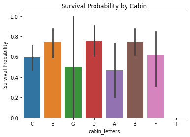

```python
sns.barplot(x = 'cabin_letters', y ='Survived', data = training)
plt.ylabel('Survival Probability')
plt.title('Survival Probability by Cabin')
```

Filling in NAN values

```python
# cabin binning
cabinMap = {"A": 0, "B": 0.4, "C": 0.8, "D": 1.2, "E": 1.6, "F": 2, "G": 2.4, "T": 2.8}
for dataset in train_test_data:
    dataset['cabin_letters'] = dataset['cabin_letters'].map(cabinMap)
```

```python
# fill missing cabins with median cabin for each Pclass
training["cabin_letters"].fillna(training.groupby("Pclass")["cabin_letters"].transform("median"), inplace=True)
test["cabin_letters"].fillna(test.groupby("Pclass")["cabin_letters"].transform("median"), inplace=True)
```

```python
training.cabin_letters.value_counts()
training.head()
```

|  | PassengerId | Survived | Pclass | Name | Sex | Age | SibSp | Parch | Ticket | Fare | Cabin | Embarked | train_test | Size_of_Family | Alone | no_cabins | cabin_letters |
| --- | --- | --- | --- | --- | --- | --- | --- | --- | --- | --- | --- | --- | --- | --- | --- | --- | --- |
| 0 | 1 | 0 | 3 | Braund, Mr. Owen Harris | 0 | 22.0 | 1 | 0 | A/5 21171 | 7.2500 | NaN | 0 | 1 | 2 | 0 | 0 | 2.0 |
| 1 | 2 | 1 | 1 | Cumings, Mrs. John Bradley (Florence Briggs Th... | 1 | 38.0 | 1 | 0 | PC 17599 | 71.2833 | C85 | 1 | 1 | 2 | 0 | 1 | 0.8 |
| 2 | 3 | 1 | 3 | Heikkinen, Miss. Laina | 1 | 26.0 | 0 | 0 | STON/O2. 3101282 | 7.9250 | NaN | 0 | 1 | 1 | 1 | 0 | 2.0 |
| 3 | 4 | 1 | 1 | Futrelle, Mrs. Jacques Heath (Lily May Peel) | 1 | 35.0 | 1 | 0 | 113803 | 53.1000 | C123 | 0 | 1 | 2 | 0 | 1 | 0.8 |
| 4 | 5 | 0 | 3 | Allen, Mr. William Henry | 0 | 35.0 | 0 | 0 | 373450 | 8.0500 | NaN | 0 | 1 | 1 | 1 | 0 | 2.0 |

### 5.3.4) New Feature: Title_class

From Name we determine if a person's title has on impact on their probability of survival. We first extract the title of the person from the passenger's name. We then classify each title by assigning them to different title classes. We then compare this to the survived column.

```python
training['title'] = training.Name.apply(lambda x: x.split(',')[1].split('.')[0].strip())# extract title
test['title'] = test.Name.apply(lambda x: x.split(',')[1].split('.')[0].strip())# extract title
training['title'].value_counts()
#Title classification: classify titles by assigning them to different classes.
title_map= {"Master": 0, "Miss": 0, "Mlle": 1, "Mrs": 1,"Ms":1, "Mme": 1,
                 "Mr": 1, "Rev": 2,"Dr": 2,"Don": 2, "Major": 3, "Col": 3, "the Countess": 4,"Lady":4,"Sir": 4,
                 "Jonkheer": 4, "Capt": 5, }
training['Title_class'] = training['title'].map(title_map) #create new feature whoch illustrates dfferent classes
test['Title_class'] = training['title'].map(title_map) #create new feature whoch illustrates dfferent classes
```

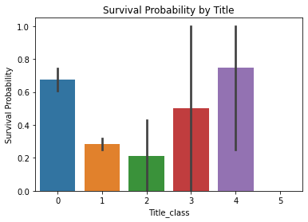

```python
sns.barplot(x = 'Title_class', y ='Survived', data = training)
plt.ylabel('Survival Probability')
plt.title('Survival Probability by Title')
```

### 5.3.5) New Feature: Title_names

Following simillar methodology of the previous title class, however it attempts to not group titles but rather provide them their unique own distinctions.

```python
training['name_title'] = training.Name.apply(lambda x: x.split(',')[1].split('.')[0].strip())
title_map= {"Master": 0, "Miss": 1, "Mlle": 2, "Mrs": 3,"Ms": 4, "Mme": 5,
                 "Mr": 6, "Rev": 7,"Dr": 8,"Don": 9, "Major": 10, "Col": 11, "the Countess": 12,"Lady": 13,"Sir": 14,
                 "Jonkheer": 15, "Capt": 16}
training['name_title'] = training['name_title'].map(title_map) #create new feature whoch illustrates dfferent classes
test['name_title'] = test.Name.apply(lambda x: x.split(',')[1].split('.')[0].strip())
test['name_title'] = test['name_title'].map(title_map) #create new feature whoch illustrates dfferent classes
test['name_title'] = test.name_title.fillna(17)
training[['name_title', 'Survived']].groupby(['name_title'], as_index = False).mean().sort_values(by = 'Survived', ascending = False)
```

|  | name_title | Survived |
| --- | --- | --- |
| 2 | 2 | 1.000000 |
| 4 | 4 | 1.000000 |
| 5 | 5 | 1.000000 |
| 14 | 14 | 1.000000 |
| 13 | 13 | 1.000000 |
| 12 | 12 | 1.000000 |
| 3 | 3 | 0.792000 |
| 1 | 1 | 0.697802 |
| 0 | 0 | 0.575000 |
| 11 | 11 | 0.500000 |
| 10 | 10 | 0.500000 |
| 8 | 8 | 0.428571 |
| 6 | 6 | 0.156673 |
| 9 | 9 | 0.000000 |
| 7 | 7 | 0.000000 |
| 15 | 15 | 0.000000 |
| 16 | 16 | 0.000000 |

### 5.3.6) New Feature: Age_median

From Age determine if a passenger's age impacts their survival rate by filling in the missing values using the median.

```python
training['Age_median'] = training.Age.fillna(training.Age.median())
test['Age_median'] = test.Age.fillna(test.Age.median())
```

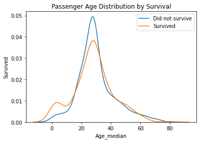

```python
sns.kdeplot(training['Age_median'][training['Survived'] == 0], label = 'Did not survive')
sns.kdeplot(training['Age_median'][training['Survived'] == 1], label = 'Survived')
plt.xlabel('Age_median')
plt.ylabel('Survived')
plt.title('Passenger Age Distribution by Survival')
plt.legend()
```

### 5.3.7) New Feature: Age_mean

From Age determine if a passenger's age impacts their survival rate by filling in the missing values using the mean.

```python
training['Age_mean'] = training.Age.fillna(training.Age.mean())
test['Age_mean'] = test.Age.fillna(test.Age.mean())
```

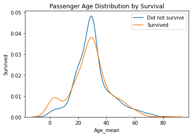

```python
sns.kdeplot(training['Age_mean'][training['Survived'] == 0], label = 'Did not survive')
sns.kdeplot(training['Age_mean'][training['Survived'] == 1], label = 'Survived')
plt.xlabel('Age_mean')
plt.ylabel('Survived')
plt.title('Passenger Age Distribution by Survival')
plt.legend()
```

### 5.3.8) New_feature: Age_group_median

Fill NAN for training set using median of Age

```python
training['age_band_median'] = pd.cut(training['Age_median'], 8) # create 8 bins of intervals = 10.
test['age_band_median'] = pd.cut(test['Age_median'], 8) # create 8 bins of intervals = 10.
training[['age_band_median', 'Survived']].groupby(['age_band_median'], as_index=False).mean().sort_values(by='age_band_median', ascending=True)
```

|  | age_band_median | Survived |
| --- | --- | --- |
| 0 | (0.34, 10.368] | 0.593750 |
| 1 | (10.368, 20.315] | 0.382609 |
| 2 | (20.315, 30.263] | 0.334152 |
| 3 | (30.263, 40.21] | 0.445161 |
| 4 | (40.21, 50.158] | 0.383721 |
| 5 | (50.158, 60.105] | 0.404762 |
| 6 | (60.105, 70.052] | 0.235294 |
| 7 | (70.052, 80.0] | 0.200000 |

The table above shows young children under the age of 10 years has the best chance of survival.

```python
for dataset in train_test_data:
    dataset.loc[ dataset['Age_median'] <= 10.368, 'Age_group_median'] = 0
    dataset.loc[(dataset['Age_median'] > 10.368) & (dataset['Age_median'] <= 20.315), 'Age_group_median'] = 1
    dataset.loc[(dataset['Age_median'] > 20.315) & (dataset['Age_median'] <= 30.263), 'Age_group_median'] = 2
    dataset.loc[(dataset['Age_median'] > 30.263) & (dataset['Age_median'] <= 40.21), 'Age_group_median'] = 3
    dataset.loc[(dataset['Age_median'] > 40.21) & (dataset['Age_median'] <= 50.158), 'Age_group_median'] = 4
    dataset.loc[(dataset['Age_median'] > 50.158) & (dataset['Age_median'] <= 60.105), 'Age_group_median'] = 5
    dataset.loc[(dataset['Age_median'] > 60.105) & (dataset['Age_median'] <= 70.052), 'Age_group_median'] = 6
    dataset.loc[ dataset['Age_median'] > 70.052, 'Age_group_median'] = 7
```

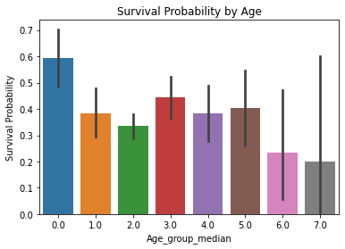

```python
sns.barplot(x = 'Age_group_median', y ='Survived', data = training)
plt.ylabel('Survival Probability')
plt.title('Survival Probability by Age')
```

### 5.3.9) New feature: Age_group_mean

Age_median and Age_mean show no clear difference, however, the size of the bands could.

```python
training['age_band_mean'] = pd.cut(training['Age_mean'], 16) # create 16 bins of intervals = 5.
test['age_band_mean'] = pd.cut(test['Age_mean'], 16) # create 16 bins of intervals = 5.
training[['age_band_mean', 'Survived']].groupby(['age_band_mean'], as_index=False).mean().sort_values(by='age_band_mean', ascending=True)
```

|  | age_band_mean | Survived |
| --- | --- | --- |
| 0 | (0.34, 5.394] | 0.704545 |
| 1 | (5.394, 10.368] | 0.350000 |
| 2 | (10.368, 15.341] | 0.578947 |
| 3 | (15.341, 20.315] | 0.343750 |
| 4 | (20.315, 25.289] | 0.344262 |
| 5 | (25.289, 30.263] | 0.329825 |
| 6 | (30.263, 35.236] | 0.465909 |
| 7 | (35.236, 40.21] | 0.417910 |
| 8 | (40.21, 45.184] | 0.361702 |
| 9 | (45.184, 50.158] | 0.410256 |
| 10 | (50.158, 55.131] | 0.416667 |
| 11 | (55.131, 60.105] | 0.388889 |
| 12 | (60.105, 65.079] | 0.285714 |
| 13 | (65.079, 70.052] | 0.000000 |
| 14 | (70.052, 75.026] | 0.000000 |
| 15 | (75.026, 80.0] | 1.000000 |

```python
for dataset in train_test_data:
    dataset.loc[ dataset['Age_mean'] <= 10.368, 'Age_group_mean'] = 0
    dataset.loc[(dataset['Age_mean'] > 10.368) & (dataset['Age_mean'] <= 20.315), 'Age_group_mean'] = 1
    dataset.loc[(dataset['Age_mean'] > 20.315) & (dataset['Age_mean'] <= 30.263), 'Age_group_mean'] = 2
    dataset.loc[(dataset['Age_mean'] > 30.263) & (dataset['Age_mean'] <= 40.21), 'Age_group_mean'] = 3
    dataset.loc[(dataset['Age_mean'] > 40.21) & (dataset['Age_mean'] <= 50.158), 'Age_group_mean'] = 4
    dataset.loc[(dataset['Age_mean'] > 50.158) & (dataset['Age_mean'] <= 60.105), 'Age_group_mean'] = 5
    dataset.loc[(dataset['Age_mean'] > 60.105) & (dataset['Age_mean'] <= 70.052), 'Age_group_mean'] = 6
    dataset.loc[ dataset['Age_mean'] > 70.052, 'Age_group_mean'] = 7
```

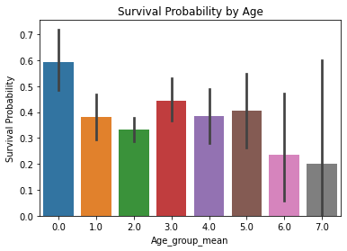

```python
sns.barplot(x = 'Age_group_mean', y ='Survived', data = training)
plt.ylabel('Survival Probability')
plt.title('Survival Probability by Age')
```

### 5.3.10) Fare

```python
#fill NaN for Fare in test
test['Fare'] = test.Fare.fillna(test.Fare.mean())

# fare binning
for dataset in train_test_data:
    dataset.loc[ dataset['Fare'] <= 17, 'FareBins'] = 0
    dataset.loc[(dataset['Fare'] > 17) & (dataset['Fare'] <= 30), 'FareBins'] = 1
    dataset.loc[(dataset['Fare'] > 30) & (dataset['Fare'] <= 100), 'FareBins'] = 2
    dataset.loc[ dataset['Fare'] > 100, 'FareBins'] = 3
```

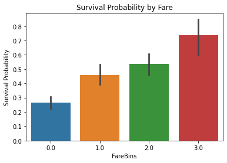

```python
sns.barplot(x = 'FareBins', y ='Survived', data = training)
plt.ylabel('Survival Probability')
plt.title('Survival Probability by Fare')
```

### 5.3.11) Fare Normalisation

Attempting to achieve a normalised distribution of the fare values.

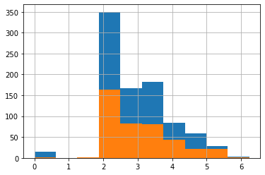

```python
training['norm_fare'] = np.log(training.Fare+1)
test['norm_fare'] = np.log(test.Fare+1)
training['norm_fare'].hist()
test['norm_fare'].hist()
```

```python
training.info()
```

```
<class 'pandas.core.frame.DataFrame'>
RangeIndex: 891 entries, 0 to 890
Data columns (total 28 columns):
 #   Column            Non-Null Count  Dtype
---  ------            --------------  -----
 0   PassengerId       891 non-null    int64
 1   Survived          891 non-null    int64
 2   Pclass            891 non-null    int64
 3   Name              891 non-null    object
 4   Sex               891 non-null    int64
 5   Age               714 non-null    float64
 6   SibSp             891 non-null    int64
 7   Parch             891 non-null    int64
 8   Ticket            891 non-null    object
 9   Fare              891 non-null    float64
```

[output cut: 20 more lines]

```python
test.info()
```

```
<class 'pandas.core.frame.DataFrame'>
RangeIndex: 418 entries, 0 to 417
Data columns (total 28 columns):
 #   Column            Non-Null Count  Dtype
---  ------            --------------  -----
 0   PassengerId       418 non-null    int64
 1   Pclass            418 non-null    int64
 2   Name              418 non-null    object
 3   Sex               418 non-null    int64
 4   Age               332 non-null    float64
 5   SibSp             418 non-null    int64
 6   Parch             418 non-null    int64
 7   Ticket            418 non-null    object
 8   Fare              418 non-null    float64
 9   Cabin             91 non-null     object
```

[output cut: 20 more lines]

## 5.4 Selection of different Feature Engineering techniques:

The same data frame as from no feature engineering and dropping NaN columns, except with the **Size_of_Family** feature replacing **'SibSp','Parch'**

```python
fe2 = training[['Size_of_Family','Fare','Survived','Pclass','Sex','Embarked']]
fe2_test = test[['Size_of_Family','Fare','Pclass','Sex','Embarked']]
fe2
```

|  | Size_of_Family | Fare | Survived | Pclass | Sex | Embarked |
| --- | --- | --- | --- | --- | --- | --- |
| 0 | 2 | 7.2500 | 0 | 3 | 0 | 0 |
| 1 | 2 | 71.2833 | 1 | 1 | 1 | 1 |
| 2 | 1 | 7.9250 | 1 | 3 | 1 | 0 |
| 3 | 2 | 53.1000 | 1 | 1 | 1 | 0 |
| 4 | 1 | 8.0500 | 0 | 3 | 0 | 0 |
| ... | ... | ... | ... | ... | ... | ... |
| 886 | 1 | 13.0000 | 0 | 2 | 0 | 0 |
| 887 | 1 | 30.0000 | 1 | 1 | 1 | 0 |
| 888 | 4 | 23.4500 | 0 | 3 | 1 | 0 |
| 889 | 1 | 30.0000 | 1 | 1 | 0 | 1 |
| 890 | 1 | 7.7500 | 0 | 3 | 0 | 2 |

891 rows × 6 columns

The same data frame as from no feature engineering and dropping NaN columns, except with the **FareBins** feature replacing **Fare**

```python
fe3 = training[['SibSp','Parch','FareBins','Survived','Pclass','Sex','Embarked']]
fe3_test = test[['SibSp','Parch','FareBins','Pclass','Sex','Embarked']]
fe3
```

|  | SibSp | Parch | FareBins | Survived | Pclass | Sex | Embarked |
| --- | --- | --- | --- | --- | --- | --- | --- |
| 0 | 1 | 0 | 0.0 | 0 | 3 | 0 | 0 |
| 1 | 1 | 0 | 2.0 | 1 | 1 | 1 | 1 |
| 2 | 0 | 0 | 0.0 | 1 | 3 | 1 | 0 |
| 3 | 1 | 0 | 2.0 | 1 | 1 | 1 | 0 |
| 4 | 0 | 0 | 0.0 | 0 | 3 | 0 | 0 |
| ... | ... | ... | ... | ... | ... | ... | ... |
| 886 | 0 | 0 | 0.0 | 0 | 2 | 0 | 0 |
| 887 | 0 | 0 | 1.0 | 1 | 1 | 1 | 0 |
| 888 | 1 | 2 | 1.0 | 0 | 3 | 1 | 0 |
| 889 | 0 | 0 | 1.0 | 1 | 1 | 0 | 1 |
| 890 | 0 | 0 | 0.0 | 0 | 3 | 0 | 2 |

891 rows × 7 columns

The same data frame as from no feature engineering and dropping NaN columns, except with replacing the dropped **Cabin** with **'no_cabins','cabin_letters'** feature

```python
fe4 = training[['SibSp','Parch','Fare','Survived','Pclass','Sex','Embarked','no_cabins','cabin_letters']]
fe4_test = test[['SibSp','Parch','Fare','Pclass','Sex','Embarked','no_cabins','cabin_letters']]
fe4
```

|  | SibSp | Parch | Fare | Survived | Pclass | Sex | Embarked | no_cabins | cabin_letters |
| --- | --- | --- | --- | --- | --- | --- | --- | --- | --- |
| 0 | 1 | 0 | 7.2500 | 0 | 3 | 0 | 0 | 0 | 2.0 |
| 1 | 1 | 0 | 71.2833 | 1 | 1 | 1 | 1 | 1 | 0.8 |
| 2 | 0 | 0 | 7.9250 | 1 | 3 | 1 | 0 | 0 | 2.0 |
| 3 | 1 | 0 | 53.1000 | 1 | 1 | 1 | 0 | 1 | 0.8 |
| 4 | 0 | 0 | 8.0500 | 0 | 3 | 0 | 0 | 0 | 2.0 |
| ... | ... | ... | ... | ... | ... | ... | ... | ... | ... |
| 886 | 0 | 0 | 13.0000 | 0 | 2 | 0 | 0 | 0 | 1.8 |
| 887 | 0 | 0 | 30.0000 | 1 | 1 | 1 | 0 | 1 | 0.4 |
| 888 | 1 | 2 | 23.4500 | 0 | 3 | 1 | 0 | 0 | 2.0 |
| 889 | 0 | 0 | 30.0000 | 1 | 1 | 0 | 1 | 1 | 0.8 |
| 890 | 0 | 0 | 7.7500 | 0 | 3 | 0 | 2 | 0 | 2.0 |

891 rows × 9 columns

The same data frame as from no feature engineering and dropping NaN columns, except with replacing the dropped **Age** with **Age_median** feature

```python
fe5 = training[['Age_median','SibSp','Parch','Fare','Survived','Pclass','Sex','Embarked']]
fe5_test = test[['Age_median','SibSp','Parch','Fare','Pclass','Sex','Embarked']]
fe5
```

|  | Age_median | SibSp | Parch | Fare | Survived | Pclass | Sex | Embarked |
| --- | --- | --- | --- | --- | --- | --- | --- | --- |
| 0 | 22.0 | 1 | 0 | 7.2500 | 0 | 3 | 0 | 0 |
| 1 | 38.0 | 1 | 0 | 71.2833 | 1 | 1 | 1 | 1 |
| 2 | 26.0 | 0 | 0 | 7.9250 | 1 | 3 | 1 | 0 |
| 3 | 35.0 | 1 | 0 | 53.1000 | 1 | 1 | 1 | 0 |
| 4 | 35.0 | 0 | 0 | 8.0500 | 0 | 3 | 0 | 0 |
| ... | ... | ... | ... | ... | ... | ... | ... | ... |
| 886 | 27.0 | 0 | 0 | 13.0000 | 0 | 2 | 0 | 0 |
| 887 | 19.0 | 0 | 0 | 30.0000 | 1 | 1 | 1 | 0 |
| 888 | 28.0 | 1 | 2 | 23.4500 | 0 | 3 | 1 | 0 |
| 889 | 26.0 | 0 | 0 | 30.0000 | 1 | 1 | 0 | 1 |
| 890 | 32.0 | 0 | 0 | 7.7500 | 0 | 3 | 0 | 2 |

891 rows × 8 columns

The same data frame as from no feature engineering and dropping NaN columns, except with replacing the dropped **Age** with **Age_mean** feature

```python
fe6 = training[['Age_mean','SibSp','Parch','Fare','Survived','Pclass','Sex','Embarked']]
fe6_test = test[['Age_mean','SibSp','Parch','Fare','Pclass','Sex','Embarked']]
fe6
```

|  | Age_mean | SibSp | Parch | Fare | Survived | Pclass | Sex | Embarked |
| --- | --- | --- | --- | --- | --- | --- | --- | --- |
| 0 | 22.000000 | 1 | 0 | 7.2500 | 0 | 3 | 0 | 0 |
| 1 | 38.000000 | 1 | 0 | 71.2833 | 1 | 1 | 1 | 1 |
| 2 | 26.000000 | 0 | 0 | 7.9250 | 1 | 3 | 1 | 0 |
| 3 | 35.000000 | 1 | 0 | 53.1000 | 1 | 1 | 1 | 0 |
| 4 | 35.000000 | 0 | 0 | 8.0500 | 0 | 3 | 0 | 0 |
| ... | ... | ... | ... | ... | ... | ... | ... | ... |
| 886 | 27.000000 | 0 | 0 | 13.0000 | 0 | 2 | 0 | 0 |
| 887 | 19.000000 | 0 | 0 | 30.0000 | 1 | 1 | 1 | 0 |
| 888 | 29.699118 | 1 | 2 | 23.4500 | 0 | 3 | 1 | 0 |
| 889 | 26.000000 | 0 | 0 | 30.0000 | 1 | 1 | 0 | 1 |
| 890 | 32.000000 | 0 | 0 | 7.7500 | 0 | 3 | 0 | 2 |

891 rows × 8 columns

As Age is a column that a lot of NaN values need to get replaced, that feature will be studied in detail in conjunction with the other features that were created

**'Age_median'** with all other feature engineering aspects added:

```python
fe7 = training[['Size_of_Family','Alone','no_cabins','cabin_letters','Title_class','Age_median','FareBins', 'Pclass','Sex','Embarked','Survived']]
fe7_test = test[['Size_of_Family','Alone','no_cabins','cabin_letters','Title_class','Age_median','FareBins', 'Pclass','Sex','Embarked']]
fe7
```

|  | Size_of_Family | Alone | no_cabins | cabin_letters | Title_class | Age_median | FareBins | Pclass | Sex | Embarked | Survived |
| --- | --- | --- | --- | --- | --- | --- | --- | --- | --- | --- | --- |
| 0 | 2 | 0 | 0 | 2.0 | 1 | 22.0 | 0.0 | 3 | 0 | 0 | 0 |
| 1 | 2 | 0 | 1 | 0.8 | 1 | 38.0 | 2.0 | 1 | 1 | 1 | 1 |
| 2 | 1 | 1 | 0 | 2.0 | 0 | 26.0 | 0.0 | 3 | 1 | 0 | 1 |
| 3 | 2 | 0 | 1 | 0.8 | 1 | 35.0 | 2.0 | 1 | 1 | 0 | 1 |
| 4 | 1 | 1 | 0 | 2.0 | 1 | 35.0 | 0.0 | 3 | 0 | 0 | 0 |
| ... | ... | ... | ... | ... | ... | ... | ... | ... | ... | ... | ... |
| 886 | 1 | 1 | 0 | 1.8 | 2 | 27.0 | 0.0 | 2 | 0 | 0 | 0 |
| 887 | 1 | 1 | 1 | 0.4 | 0 | 19.0 | 1.0 | 1 | 1 | 0 | 1 |
| 888 | 4 | 0 | 0 | 2.0 | 0 | 28.0 | 1.0 | 3 | 1 | 0 | 0 |
| 889 | 1 | 1 | 1 | 0.8 | 1 | 26.0 | 1.0 | 1 | 0 | 1 | 1 |
| 890 | 1 | 1 | 0 | 2.0 | 1 | 32.0 | 0.0 | 3 | 0 | 2 | 0 |

891 rows × 11 columns

**'Age_mean'** with all other feature engineering aspects added:

```python
fe8 = training[['Size_of_Family','Alone','no_cabins','cabin_letters','Title_class','Age_mean','FareBins', 'Pclass','Sex','Embarked','Survived']]
fe8_test = test[['Size_of_Family','Alone','no_cabins','cabin_letters','Title_class','Age_mean','FareBins', 'Pclass','Sex','Embarked']]
fe8
```

|  | Size_of_Family | Alone | no_cabins | cabin_letters | Title_class | Age_mean | FareBins | Pclass | Sex | Embarked | Survived |
| --- | --- | --- | --- | --- | --- | --- | --- | --- | --- | --- | --- |
| 0 | 2 | 0 | 0 | 2.0 | 1 | 22.000000 | 0.0 | 3 | 0 | 0 | 0 |
| 1 | 2 | 0 | 1 | 0.8 | 1 | 38.000000 | 2.0 | 1 | 1 | 1 | 1 |
| 2 | 1 | 1 | 0 | 2.0 | 0 | 26.000000 | 0.0 | 3 | 1 | 0 | 1 |
| 3 | 2 | 0 | 1 | 0.8 | 1 | 35.000000 | 2.0 | 1 | 1 | 0 | 1 |
| 4 | 1 | 1 | 0 | 2.0 | 1 | 35.000000 | 0.0 | 3 | 0 | 0 | 0 |
| ... | ... | ... | ... | ... | ... | ... | ... | ... | ... | ... | ... |
| 886 | 1 | 1 | 0 | 1.8 | 2 | 27.000000 | 0.0 | 2 | 0 | 0 | 0 |
| 887 | 1 | 1 | 1 | 0.4 | 0 | 19.000000 | 1.0 | 1 | 1 | 0 | 1 |
| 888 | 4 | 0 | 0 | 2.0 | 0 | 29.699118 | 1.0 | 3 | 1 | 0 | 0 |
| 889 | 1 | 1 | 1 | 0.8 | 1 | 26.000000 | 1.0 | 1 | 0 | 1 | 1 |
| 890 | 1 | 1 | 0 | 2.0 | 1 | 32.000000 | 0.0 | 3 | 0 | 2 | 0 |

891 rows × 11 columns

**'Age_group_median'** with all other feature engineering aspects added:

```python
fe9 = training[['Size_of_Family','Alone','no_cabins','cabin_letters','Title_class','Age_group_median','FareBins', 'Pclass','Sex','Embarked','Survived']]
fe9_test = test[['Size_of_Family','Alone','no_cabins','cabin_letters','Title_class','Age_group_median','FareBins', 'Pclass','Sex','Embarked']]
fe9
```

|  | Size_of_Family | Alone | no_cabins | cabin_letters | Title_class | Age_group_median | FareBins | Pclass | Sex | Embarked | Survived |
| --- | --- | --- | --- | --- | --- | --- | --- | --- | --- | --- | --- |
| 0 | 2 | 0 | 0 | 2.0 | 1 | 2.0 | 0.0 | 3 | 0 | 0 | 0 |
| 1 | 2 | 0 | 1 | 0.8 | 1 | 3.0 | 2.0 | 1 | 1 | 1 | 1 |
| 2 | 1 | 1 | 0 | 2.0 | 0 | 2.0 | 0.0 | 3 | 1 | 0 | 1 |
| 3 | 2 | 0 | 1 | 0.8 | 1 | 3.0 | 2.0 | 1 | 1 | 0 | 1 |
| 4 | 1 | 1 | 0 | 2.0 | 1 | 3.0 | 0.0 | 3 | 0 | 0 | 0 |
| ... | ... | ... | ... | ... | ... | ... | ... | ... | ... | ... | ... |
| 886 | 1 | 1 | 0 | 1.8 | 2 | 2.0 | 0.0 | 2 | 0 | 0 | 0 |
| 887 | 1 | 1 | 1 | 0.4 | 0 | 1.0 | 1.0 | 1 | 1 | 0 | 1 |
| 888 | 4 | 0 | 0 | 2.0 | 0 | 2.0 | 1.0 | 3 | 1 | 0 | 0 |
| 889 | 1 | 1 | 1 | 0.8 | 1 | 2.0 | 1.0 | 1 | 0 | 1 | 1 |
| 890 | 1 | 1 | 0 | 2.0 | 1 | 3.0 | 0.0 | 3 | 0 | 2 | 0 |

891 rows × 11 columns

**'Age_group_mean'** with all other feature engineering aspects added:

```python
fe10 = training[['Size_of_Family','Alone','no_cabins','cabin_letters','Title_class','Age_group_mean','FareBins', 'Pclass','Sex','Embarked','Survived']]
fe10_test = test[['Size_of_Family','Alone','no_cabins','cabin_letters','Title_class','Age_group_mean','FareBins', 'Pclass','Sex','Embarked']]
fe10
```

|  | Size_of_Family | Alone | no_cabins | cabin_letters | Title_class | Age_group_mean | FareBins | Pclass | Sex | Embarked | Survived |
| --- | --- | --- | --- | --- | --- | --- | --- | --- | --- | --- | --- |
| 0 | 2 | 0 | 0 | 2.0 | 1 | 2.0 | 0.0 | 3 | 0 | 0 | 0 |
| 1 | 2 | 0 | 1 | 0.8 | 1 | 3.0 | 2.0 | 1 | 1 | 1 | 1 |
| 2 | 1 | 1 | 0 | 2.0 | 0 | 2.0 | 0.0 | 3 | 1 | 0 | 1 |
| 3 | 2 | 0 | 1 | 0.8 | 1 | 3.0 | 2.0 | 1 | 1 | 0 | 1 |
| 4 | 1 | 1 | 0 | 2.0 | 1 | 3.0 | 0.0 | 3 | 0 | 0 | 0 |
| ... | ... | ... | ... | ... | ... | ... | ... | ... | ... | ... | ... |
| 886 | 1 | 1 | 0 | 1.8 | 2 | 2.0 | 0.0 | 2 | 0 | 0 | 0 |
| 887 | 1 | 1 | 1 | 0.4 | 0 | 1.0 | 1.0 | 1 | 1 | 0 | 1 |
| 888 | 4 | 0 | 0 | 2.0 | 0 | 2.0 | 1.0 | 3 | 1 | 0 | 0 |
| 889 | 1 | 1 | 1 | 0.8 | 1 | 2.0 | 1.0 | 1 | 0 | 1 | 1 |
| 890 | 1 | 1 | 0 | 2.0 | 1 | 3.0 | 0.0 | 3 | 0 | 2 | 0 |

891 rows × 11 columns

Feature engineered columns that have been scaled

```python
fe11 = training[['Size_of_Family','Alone','no_cabins','cabin_letters','Title_class','Age_mean','FareBins', 'Pclass','Sex','Embarked','Survived']]
fe11 = preprocessing.StandardScaler().fit(fe11).transform(fe11)
fe11_test = test[['Size_of_Family','Alone','no_cabins','cabin_letters','Title_class','Age_mean','FareBins', 'Pclass','Sex','Embarked']]
fe11
```

```
array([[ 0.05915988, -1.2316449 , -0.48848295, ..., -0.73769513,
        -0.56883712, -0.78927234],
       [ 0.05915988, -1.2316449 ,  1.34024943, ...,  1.35557354,
         1.00518113,  1.2669898 ],
       [-0.56097483,  0.81192233, -0.48848295, ...,  1.35557354,
        -0.56883712,  1.2669898 ],
       ...,
       [ 1.29942929, -1.2316449 , -0.48848295, ...,  1.35557354,
        -0.56883712, -0.78927234],
       [-0.56097483,  0.81192233,  1.34024943, ..., -0.73769513,
         1.00518113,  1.2669898 ],
       [-0.56097483,  0.81192233, -0.48848295, ..., -0.73769513,
         2.57919938, -0.78927234]])
```

```python
fe12 = training[['Alone','Age_group_mean','Pclass','Sex','Survived']]
fe12_test = test[['Alone','Age_group_mean','Pclass','Sex']]
fe12
```

|  | Alone | Age_group_mean | Pclass | Sex | Survived |
| --- | --- | --- | --- | --- | --- |
| 0 | 0 | 2.0 | 3 | 0 | 0 |
| 1 | 0 | 3.0 | 1 | 1 | 1 |
| 2 | 1 | 2.0 | 3 | 1 | 1 |
| 3 | 0 | 3.0 | 1 | 1 | 1 |
| 4 | 1 | 3.0 | 3 | 0 | 0 |
| ... | ... | ... | ... | ... | ... |
| 886 | 1 | 2.0 | 2 | 0 | 0 |
| 887 | 1 | 1.0 | 1 | 1 | 1 |
| 888 | 0 | 2.0 | 3 | 1 | 0 |
| 889 | 1 | 2.0 | 1 | 0 | 1 |
| 890 | 1 | 3.0 | 3 | 0 | 0 |

891 rows × 5 columns

```python
fe13 = training[['Survived','Pclass','Sex','Age_mean','Alone','Fare','Embarked']]
fe13_test = test[['Pclass','Sex','Age_mean','Alone','Fare','Embarked']]
fe13
```

|  | Survived | Pclass | Sex | Age_mean | Alone | Fare | Embarked |
| --- | --- | --- | --- | --- | --- | --- | --- |
| 0 | 0 | 3 | 0 | 22.000000 | 0 | 7.2500 | 0 |
| 1 | 1 | 1 | 1 | 38.000000 | 0 | 71.2833 | 1 |
| 2 | 1 | 3 | 1 | 26.000000 | 1 | 7.9250 | 0 |
| 3 | 1 | 1 | 1 | 35.000000 | 0 | 53.1000 | 0 |
| 4 | 0 | 3 | 0 | 35.000000 | 1 | 8.0500 | 0 |
| ... | ... | ... | ... | ... | ... | ... | ... |
| 886 | 0 | 2 | 0 | 27.000000 | 1 | 13.0000 | 0 |
| 887 | 1 | 1 | 1 | 19.000000 | 1 | 30.0000 | 0 |
| 888 | 0 | 3 | 1 | 29.699118 | 0 | 23.4500 | 0 |
| 889 | 1 | 1 | 0 | 26.000000 | 1 | 30.0000 | 1 |
| 890 | 0 | 3 | 0 | 32.000000 | 1 | 7.7500 | 2 |

891 rows × 7 columns

```python
fe14 = training[['Survived','Pclass','Sex','Age_mean','Alone','Fare','Embarked','name_title']]
fe14_test = test[['Pclass','Sex','Age_mean','Alone','Fare','Embarked','name_title']]
fe14

fe14_test.isnull().sum().sort_values(ascending = False)
```

```
Pclass        0
Sex           0
Age_mean      0
Alone         0
Fare          0
Embarked      0
name_title    0
dtype: int64
```

```python
fe15 = training[['Survived','Pclass','Sex','Age','Alone','Fare','Embarked']]
NaN = -1
fe15.Age.fillna(NaN, inplace=True)
fe15_test = test[['Pclass','Sex','Age','Alone','Fare','Embarked']]
fe15_test.Age.fillna(NaN, inplace=True)
fe15
```

|  | Survived | Pclass | Sex | Age | Alone | Fare | Embarked |
| --- | --- | --- | --- | --- | --- | --- | --- |
| 0 | 0 | 3 | 0 | 22.0 | 0 | 7.2500 | 0 |
| 1 | 1 | 1 | 1 | 38.0 | 0 | 71.2833 | 1 |
| 2 | 1 | 3 | 1 | 26.0 | 1 | 7.9250 | 0 |
| 3 | 1 | 1 | 1 | 35.0 | 0 | 53.1000 | 0 |
| 4 | 0 | 3 | 0 | 35.0 | 1 | 8.0500 | 0 |
| ... | ... | ... | ... | ... | ... | ... | ... |
| 886 | 0 | 2 | 0 | 27.0 | 1 | 13.0000 | 0 |
| 887 | 1 | 1 | 1 | 19.0 | 1 | 30.0000 | 0 |
| 888 | 0 | 3 | 1 | -1.0 | 0 | 23.4500 | 0 |
| 889 | 1 | 1 | 0 | 26.0 | 1 | 30.0000 | 1 |
| 890 | 0 | 3 | 0 | 32.0 | 1 | 7.7500 | 2 |

891 rows × 7 columns

## 5.5 End of Feature Engineering:

```python
featureEngineering = [fe0, fe1, fe2, fe3, fe4, fe5, fe6, fe7, fe8, fe9, fe10, fe11, fe12, fe13, fe14, fe15]
testFeatureEngineering = [fe0_test, fe1_test, fe2_test, fe3_test, fe4_test, fe5_test, fe6_test, fe7_test, fe8_test, fe9_test, fe10_test, fe11_test, fe12_test, fe13_test, fe14_test, fe15_test]
```

# 6 MODEL BUILDING

This section focuses on building the models used to determine survival rates. Models must be fitted to the training set and then can be applied to the test set for obtaining results. Firstly, the provided training set is split into sections for training and validation of the models ability. Overfitting is the process by which the Machine Learning algorithm effectively learns too much from the training set, and thus even includes noise in the data, this is why preprocessing is so important.

These algorithms are all supervised methods as labels are included with the data.

```python
validationAccuracy = []
actualAccuracy = []

# default
y = training['Survived']
```

**Accuracy and Error:**

The accuracy for the training and validaton sets are shown for different datasets that make use of various parameters. These parameters vary consequetively with datasets affecting each model differently. Each parameter contains differing parameters that provide insight into the differing characteristics of each model.

Accuracy is obtained by comparing the model predictions with the actual data. Error is obtained using the mean square error.

## 6.1 Logistic Regression:

A fundamental classification technique similar to linear regression and is well suited to binary classifications. This technique makes use of the natural logirithm and the sigmoid function to predict outcomes. As such, the value of the prediction function is close to 0 or 1, since it is the sigmoid function of a linear function, weighted by the estimator inputs. [Learn more](https://realpython.com/logistic-regression-python/).

```python
logreg_acc = []
Y_pred_logreg = []
validation_acc = []
training_acc = []
mse_valid = []
mse_train = []

for i in range(len(featureEngineering)):
    if type(featureEngineering[i]) != np.ndarray:
        feature = featureEngineering[i].copy(deep=True)
        X = feature.drop(columns= ['Survived'])
        y = feature['Survived']
    test_data_log = testFeatureEngineering[i].copy(deep=True)

    # validation
    X_train,X_test,y_train,y_test=train_test_split(X,y,test_size=0.2,random_state=1)
    logreg = LogisticRegression()
    logreg.fit(X_train, y_train)
    Y_pred = logreg.predict(X_test)

    # accuracy
    print('Accuracy for fe' + str(i))
    a1 = metrics.accuracy_score(y_train, logreg.predict(X_train))
    print("Train set Accuracy: ", a1)
    a2 = metrics.accuracy_score(y_test, Y_pred)
    print("Test set Accuracy: ", a2)
    a3 = f1_score(y_test, Y_pred, average='weighted')
    print('F1 Score:', a3)
    a4 = cross_val_score(logreg,X_train,y_train,cv=5)
    a4 = a4.mean()
    print('Cross-val mean: ', a4)
    mean_acc = round(((a1 + a2 + a3 + a4)/4) * 100, 2)
    logreg_acc.append(mean_acc)
    print('logreg has a mean accuracy score of: ' + str(mean_acc) + '%\n')
    validationAccuracy.append(mean_acc)

    validation_acc.append(a2)
    training_acc.append(a1)
    mse_valid.append(mean_squared_error(y_test, Y_pred))
    mse_train.append(mean_squared_error(y_train, logreg.predict(X_train)))

    # actual
    logreg.fit(X, y)
    cols = list(test_data_log.columns.values)
    for col in cols:
        test_data_log[col].fillna(test_data_log[col].mean(), inplace=True)
    Y_pred = logreg.predict(test_data_log)
    Y_pred_logreg.append(Y_pred)

logreg_acc_max = max(logreg_acc)

for i in range (len(logreg_acc)):
    if logreg_acc[i] == logreg_acc_max :
        logreg_acc_max_index = i

print('The best accuracy score was: ' + str(logreg_acc_max))
```

```
Accuracy for fe0
Train set Accuracy:  0.8047752808988764
Test set Accuracy:  0.7821229050279329
F1 Score: 0.7786200811127533
Cross-val mean:  0.8006599034768047
logreg has a mean accuracy score of: 79.15%

Accuracy for fe1
Train set Accuracy:  0.8039772727272727
Test set Accuracy:  0.7796610169491526
F1 Score: 0.777139486676327
Cross-val mean:  0.7969098277608916
logreg has a mean accuracy score of: 78.94%

Accuracy for fe2
Train set Accuracy:  0.8089887640449438
Test set Accuracy:  0.7988826815642458
F1 Score: 0.7952644995294874
Cross-val mean:  0.8006500541711811
logreg has a mean accuracy score of: 80.09%

Accuracy for fe3
Train set Accuracy:  0.8019662921348315
Test set Accuracy:  0.7821229050279329
F1 Score: 0.7786200811127533
Cross-val mean:  0.8020585048754063
logreg has a mean accuracy score of: 79.12%

Accuracy for fe4
Train set Accuracy:  0.8089887640449438
Test set Accuracy:  0.770949720670391
F1 Score: 0.7695273736078482
Cross-val mean:  0.8076824583866837
logreg has a mean accuracy score of: 78.93%

Accuracy for fe5
Train set Accuracy:  0.7991573033707865
Test set Accuracy:  0.7988826815642458
F1 Score: 0.7984258340729911
Cross-val mean:  0.8005909583374372
```

[output cut: 58 more lines]

```
Accuracy for fe14
Train set Accuracy:  0.8047752808988764
Test set Accuracy:  0.776536312849162
F1 Score: 0.773353702042496
Cross-val mean:  0.8047769132276175
logreg has a mean accuracy score of: 78.99%

Accuracy for fe15
Train set Accuracy:  0.800561797752809
Test set Accuracy:  0.7374301675977654
F1 Score: 0.733208815699985
Cross-val mean:  0.7809317443120259
logreg has a mean accuracy score of: 76.3%

The best accuracy score was: 80.27
```

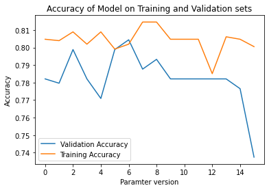

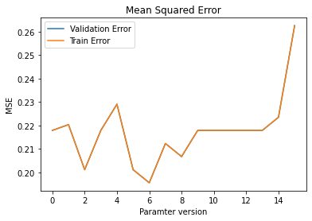

```python
Params_feats = []

for i in range (len(logreg_acc)):
    Params_feats.append(i)

plt.figure()
plt.plot(Params_feats, validation_acc, label = 'Validation Accuracy')
plt.plot(Params_feats, training_acc, label = 'Training Accuracy')
plt.xlabel('Paramter version')
plt.ylabel('Accuracy')
plt.title('Accuracy of Model on Training and Validation sets')
plt.legend(loc='best')

plt.figure()
plt.plot(Params_feats, mse_valid, label = 'Validation Error')
plt.plot(Params_feats, mse_valid, label = 'Train Error')
plt.xlabel('Paramter version')
plt.ylabel('MSE')
plt.title('Mean Squared Error')
plt.legend(loc='best')
```

## 6.2 Support Vector Machines:

In general, this algorithm is thought of as having higher accuracy over other classification algorithms and appears to perform well with higher dimensional datasets. This method creates hyper-planes to seperated data classes and constructs multiple, until it finds the best line of fit. When a single plane is unable to seperate the data, the algorithm transforms the data into a seperable form. This is not limited to linear transformations which increases the performance of the algorithm over others. [Learn more](https://datagy.io/python-support-vector-machines/)

```python
svc_acc = []
Y_pred_svc = []
validation_acc = []
training_acc = []
mse_valid = []
mse_train = []

for i in range(len(featureEngineering)):
    if type(featureEngineering[i]) != np.ndarray:
        feature = featureEngineering[i].copy(deep=True)
        X = feature.drop(columns= ['Survived'])
        y = feature['Survived']
    test_data_svc = testFeatureEngineering[i].copy(deep=True)

    # validation
    X_train,X_test,y_train,y_test=train_test_split(X,y,test_size=0.2,random_state=1)
    svc = SVC()
    svc.fit(X_train, y_train)
    Y_pred = svc.predict(X_test)

    # accuracy
    print('Accuracy for fe' + str(i))
    a1 = metrics.accuracy_score(y_train, svc.predict(X_train))
    print("Train set Accuracy: ", a1)
    a2 = metrics.accuracy_score(y_test, Y_pred)
    print("Test set Accuracy: ", a2)
    a3 = f1_score(y_test, Y_pred, average='weighted')
    print('F1 Score:', a3)
    a4 = cross_val_score(svc,X_train,y_train,cv=5)
    a4 = a4.mean()
    print('Cross-val mean: ', a4)
    mean_acc = round(((a1 + a2 + a3 + a4)/4) * 100, 2)
    svc_acc.append(mean_acc)
    print('svc has a mean accuracy score of: ' + str(mean_acc) + '%\n')
    validationAccuracy.append(mean_acc)

    validation_acc.append(a2)
    training_acc.append(a1)
    mse_valid.append(mean_squared_error(y_test, Y_pred))
    mse_train.append(mean_squared_error(y_train, svc.predict(X_train)))

    # actual
    svc.fit(X, y)
    cols = list(test_data_svc.columns.values)
    for col in cols:
        test_data_svc[col].fillna(test_data_svc[col].mean(), inplace=True)
    Y_pred = svc.predict(test_data_svc)
    Y_pred_svc.append(Y_pred)

svc_acc_max = max(svc_acc)

for i in range (len(svc_acc)):
    if svc_acc[i] == svc_acc_max :
        svc_acc_max_index = i

print('The best accuracy score was: ' + str(svc_acc_max))
```

```
Accuracy for fe0
Train set Accuracy:  0.6882022471910112
Test set Accuracy:  0.6312849162011173
F1 Score: 0.575022583163046
Cross-val mean:  0.6713582192455432
svc has a mean accuracy score of: 64.15%

Accuracy for fe1
Train set Accuracy:  0.6846590909090909
Test set Accuracy:  0.6666666666666666
F1 Score: 0.6162012279659338
Cross-val mean:  0.6861195542046605
svc has a mean accuracy score of: 66.34%

Accuracy for fe2
Train set Accuracy:  0.6882022471910112
Test set Accuracy:  0.6368715083798883
F1 Score: 0.5836222931194999
Cross-val mean:  0.6713582192455432
svc has a mean accuracy score of: 64.5%

Accuracy for fe3
Train set Accuracy:  0.8174157303370787
Test set Accuracy:  0.7821229050279329
F1 Score: 0.7758538034157243
Cross-val mean:  0.8104895104895105
svc has a mean accuracy score of: 79.65%

Accuracy for fe4
Train set Accuracy:  0.6882022471910112
Test set Accuracy:  0.6368715083798883
F1 Score: 0.5836222931194999
Cross-val mean:  0.6713582192455432
svc has a mean accuracy score of: 64.5%

Accuracy for fe5
Train set Accuracy:  0.6938202247191011
Test set Accuracy:  0.6536312849162011
F1 Score: 0.6123282317471382
Cross-val mean:  0.6727765192553925
```

[output cut: 58 more lines]

```
Accuracy for fe14
Train set Accuracy:  0.7148876404494382
Test set Accuracy:  0.6256983240223464
F1 Score: 0.5962517265768225
Cross-val mean:  0.6825864276568503
svc has a mean accuracy score of: 65.49%

Accuracy for fe15
Train set Accuracy:  0.6910112359550562
Test set Accuracy:  0.6424581005586593
F1 Score: 0.5920973539474254
Cross-val mean:  0.6713680685511673
svc has a mean accuracy score of: 64.92%

The best accuracy score was: 80.77
```

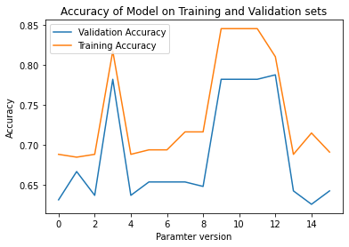

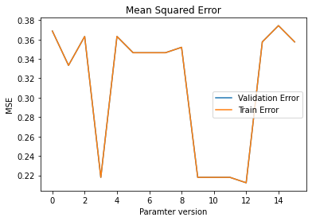

```python
Params_feats = []

for i in range (len(svc_acc)):
    Params_feats.append(i)

plt.figure()
plt.plot(Params_feats, validation_acc, label = 'Validation Accuracy')
plt.plot(Params_feats, training_acc, label = 'Training Accuracy')
plt.xlabel('Paramter version')
plt.ylabel('Accuracy')
plt.title('Accuracy of Model on Training and Validation sets')
plt.legend(loc='best')

plt.figure()
plt.plot(Params_feats, mse_valid, label = 'Validation Error')
plt.plot(Params_feats, mse_valid, label = 'Train Error')
plt.xlabel('Paramter version')
plt.ylabel('MSE')
plt.title('Mean Squared Error')
plt.legend(loc='best')
```

## 6.3 K-nearest neighbours (kNN):

This algorithm is a non-linear prediction model which means it is no limited to hyperplaning to seperate data. KNN can be used as both a classification or regression model, making it exteremely versatile. One downside of this model is that due to its complexity, large datasets are required to improve the accuracy, but it works efficiently on such large datastes. This model works at prediction rather than fitted, by which it selects values from the training set nearest (by obtaining Euclidian distance) to the new value and uses these to predict the outcome. The nearest neighbours are averaged or voted on (obtaine the mode: most commonly occuring value), depending on the problem type at hand. [Learn more](https://realpython.com/knn-python/)

```python
knn_acc = []
Y_pred_knn = []
validation_acc = []
training_acc = []
mse_valid = []
mse_train = []

for i in range(len(featureEngineering)):
    if type(featureEngineering[i]) != np.ndarray:
        feature = featureEngineering[i].copy(deep=True)
        X = feature.drop(columns= ['Survived'])
        y = feature['Survived']
    test_data = testFeatureEngineering[i].copy(deep=True)

    # validation
    X_train,X_test,y_train,y_test=train_test_split(X,y,test_size=0.2,random_state=1)
    knn = KNeighborsClassifier(n_neighbors = 5)
    knn.fit(X_train, y_train)
    Y_pred = knn.predict(X_test)

    # accuracy
    print('Accuracy for fe' + str(i))
    a1 = metrics.accuracy_score(y_train, knn.predict(X_train))
    print("Train set Accuracy: ", a1)
    a2 = metrics.accuracy_score(y_test, Y_pred)
    print("Test set Accuracy: ", a2)
    a3 = f1_score(y_test, Y_pred, average='weighted')
    print('F1 Score:', a3)
    a4 = cross_val_score(knn,X_train,y_train,cv=5)
    a4 = a4.mean()
    print('Cross-val mean: ', a4)
    mean_acc = round(((a1 + a2 + a3 + a4)/4) * 100, 2)
    knn_acc.append(mean_acc)
    print('knn has a mean accuracy score of: ' + str(mean_acc) + '%\n')
    validationAccuracy.append(mean_acc)

    validation_acc.append(a2)
    training_acc.append(a1)
    mse_valid.append(mean_squared_error(y_test, Y_pred))
    mse_train.append(mean_squared_error(y_train, knn.predict(X_train)))

    # actual
    knn.fit(X, y)
    cols = list(test_data.columns.values)
    for col in cols:
        test_data[col].fillna(test_data[col].mean(), inplace=True)
    Y_pred = knn.predict(test_data)
    Y_pred_knn.append(Y_pred)

knn_acc_max = max(knn_acc)

for i in range (len(knn_acc)):
    if knn_acc[i] == knn_acc_max :
        knn_acc_max_index = i

print('The best accuracy score was: ' + str(knn_acc_max))
```

```
Accuracy for fe0
Train set Accuracy:  0.8328651685393258
Test set Accuracy:  0.7597765363128491
F1 Score: 0.755914448406369
Cross-val mean:  0.7388456613808726
knn has a mean accuracy score of: 77.19%

Accuracy for fe1
Train set Accuracy:  0.8238636363636364
Test set Accuracy:  0.7796610169491526
F1 Score: 0.7789630284201019
Cross-val mean:  0.718774062816616
knn has a mean accuracy score of: 77.53%

Accuracy for fe2
Train set Accuracy:  0.8286516853932584
Test set Accuracy:  0.7653631284916201
F1 Score: 0.7601877778127346
Cross-val mean:  0.7458583669851275
knn has a mean accuracy score of: 77.5%

Accuracy for fe3
Train set Accuracy:  0.8300561797752809
Test set Accuracy:  0.7486033519553073
F1 Score: 0.7435796194396607
Cross-val mean:  0.8006106569486852
knn has a mean accuracy score of: 78.07%

Accuracy for fe4
Train set Accuracy:  0.8328651685393258
Test set Accuracy:  0.7262569832402235
F1 Score: 0.720786696723186
Cross-val mean:  0.7388259627696248
knn has a mean accuracy score of: 75.47%

Accuracy for fe5
Train set Accuracy:  0.7963483146067416
Test set Accuracy:  0.6871508379888268
F1 Score: 0.674104674284887
Cross-val mean:  0.7107160445188615
```

[output cut: 58 more lines]

```
Accuracy for fe14
Train set Accuracy:  0.8314606741573034
Test set Accuracy:  0.7374301675977654
F1 Score: 0.7321831580814233
Cross-val mean:  0.7430316162710529
knn has a mean accuracy score of: 76.1%

Accuracy for fe15
Train set Accuracy:  0.7823033707865169
Test set Accuracy:  0.6927374301675978
F1 Score: 0.6790458823404353
Cross-val mean:  0.6784398699891658
knn has a mean accuracy score of: 70.81%

The best accuracy score was: 79.35
```

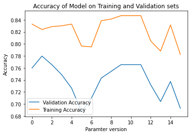

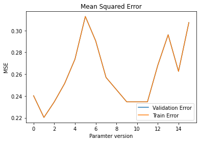

```python
Params_feats = []

for i in range (len(knn_acc)):
    Params_feats.append(i)

plt.figure()
plt.plot(Params_feats, validation_acc, label = 'Validation Accuracy')
plt.plot(Params_feats, training_acc, label = 'Training Accuracy')
plt.xlabel('Paramter version')
plt.ylabel('Accuracy')
plt.title('Accuracy of Model on Training and Validation sets')
plt.legend(loc='best')

plt.figure()
plt.plot(Params_feats, mse_valid, label = 'Validation Error')
plt.plot(Params_feats, mse_valid, label = 'Train Error')
plt.xlabel('Paramter version')
plt.ylabel('MSE')
plt.title('Mean Squared Error')
plt.legend(loc='best')
```

**Analysis:**

## 6.4 Gaussian naive bayes:

This method makes use of Bayes theorem to determine the probability of occurrence of an event, given information of other events. Modelling using this manner is particularly effective when data is of continuous nature and follows a typical Guassian distribution. It is particularly well-suited to classification problems. [Learn more](https://machinelearningknowledge.ai/gaussian-naive-bayes-implementation-in-python-sklearn/) and [here](https://scikit-learn.org/stable/modules/generated/sklearn.naive_bayes.GaussianNB.html)

```python
gaussian_acc = []
Y_pred_gaussian = []
validation_acc = []
training_acc = []
mse_valid = []
mse_train = []

for i in range(len(featureEngineering)):
    if type(featureEngineering[i]) != np.ndarray:
        feature = featureEngineering[i].copy(deep=True)
        X = feature.drop(columns= ['Survived'])
        y = feature['Survived']
    test_data = testFeatureEngineering[i].copy(deep=True)

    # validation
    X_train,X_test,y_train,y_test=train_test_split(X,y,test_size=0.2,random_state=1)
    gaussian = GaussianNB()
    gaussian.fit(X_train, y_train)
    Y_pred = gaussian.predict(X_test)

    # accuracy
    print('Accuracy for fe' + str(i))
    a1 = metrics.accuracy_score(y_train, gaussian.predict(X_train))
    print("Train set Accuracy: ", a1)
    a2 = metrics.accuracy_score(y_test, Y_pred)
    print("Test set Accuracy: ", a2)
    a3 = f1_score(y_test, Y_pred, average='weighted')
    print('F1 Score:', a3)
    a4 = cross_val_score(gaussian,X_train,y_train,cv=5)
    a4 = a4.mean()
    print('Cross-val mean: ', a4)
    mean_acc = round(((a1 + a2 + a3 + a4)/4) * 100, 2)
    gaussian_acc.append(mean_acc)
    print('gaussian has a mean accuracy score of: ' + str(mean_acc) + '%\n')
    validationAccuracy.append(mean_acc)

    validation_acc.append(a2)
    training_acc.append(a1)
    mse_valid.append(mean_squared_error(y_test, Y_pred))
    mse_train.append(mean_squared_error(y_train, gaussian.predict(X_train)))

    # actual
    gaussian.fit(X, y)
    cols = list(test_data.columns.values)
    for col in cols:
        test_data[col].fillna(test_data[col].mean(), inplace=True)
    Y_pred = gaussian.predict(test_data)
    Y_pred_gaussian.append(Y_pred)

gaussian_acc_max = max(gaussian_acc)

for i in range (len(gaussian_acc)):
    if gaussian_acc[i] == gaussian_acc_max :
        gaussian_acc_max_index = i

print('The best accuracy score was: ' + str(gaussian_acc_max))
```

```
Accuracy for fe0
Train set Accuracy:  0.7963483146067416
Test set Accuracy:  0.7653631284916201
F1 Score: 0.7628281846887628
Cross-val mean:  0.7950556485767754
gaussian has a mean accuracy score of: 77.99%

Accuracy for fe1
Train set Accuracy:  0.796875
Test set Accuracy:  0.7627118644067796
F1 Score: 0.7596072491061436
Cross-val mean:  0.7841337386018237
gaussian has a mean accuracy score of: 77.58%

Accuracy for fe2
Train set Accuracy:  0.8019662921348315
Test set Accuracy:  0.7877094972067039
F1 Score: 0.7854159766231663
Cross-val mean:  0.8006697527824288
gaussian has a mean accuracy score of: 79.39%

Accuracy for fe3
Train set Accuracy:  0.7752808988764045
Test set Accuracy:  0.7541899441340782
F1 Score: 0.755461700299455
Cross-val mean:  0.7739682852358909
gaussian has a mean accuracy score of: 76.47%

Accuracy for fe4
Train set Accuracy:  0.7752808988764045
Test set Accuracy:  0.7094972067039106
F1 Score: 0.7042709437648151
Cross-val mean:  0.7598739288880135
gaussian has a mean accuracy score of: 73.72%

Accuracy for fe5
Train set Accuracy:  0.7949438202247191
Test set Accuracy:  0.770949720670391
F1 Score: 0.7688428884962742
Cross-val mean:  0.7950654978823992
```

[output cut: 58 more lines]

```
Accuracy for fe14
Train set Accuracy:  0.797752808988764
Test set Accuracy:  0.7486033519553073
F1 Score: 0.749329908531012
Cross-val mean:  0.7907908992416035
gaussian has a mean accuracy score of: 77.16%

Accuracy for fe15
Train set Accuracy:  0.7823033707865169
Test set Accuracy:  0.7597765363128491
F1 Score: 0.7567774125795288
Cross-val mean:  0.7711415345218162
gaussian has a mean accuracy score of: 76.75%

The best accuracy score was: 79.39
```

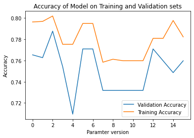

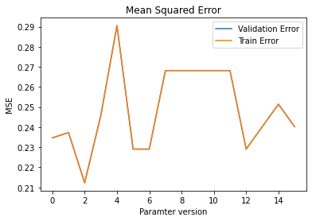

```python
Params_feats = []

for i in range (len(gaussian_acc)):
    Params_feats.append(i)

plt.figure()
plt.plot(Params_feats, validation_acc, label = 'Validation Accuracy')
plt.plot(Params_feats, training_acc, label = 'Training Accuracy')
plt.xlabel('Paramter version')
plt.ylabel('Accuracy')
plt.title('Accuracy of Model on Training and Validation sets')
plt.legend(loc='best')

plt.figure()
plt.plot(Params_feats, mse_valid, label = 'Validation Error')
plt.plot(Params_feats, mse_valid, label = 'Train Error')
plt.xlabel('Paramter version')
plt.ylabel('MSE')
plt.title('Mean Squared Error')
plt.legend(loc='best')
```

**Analysis:**

## 6.5 Perceptron:

This method is inspired by the functionality of a neuron and acts by forming a hyperplane between data for classification, thus acting in a similar way to a linear regression model. It is possible to create a layer of these "neurons" to handle data effectively. The unit step function is made use of to predict the outcome. A disadvantage is that it is confined to linear solutions. [Learn more](https://towardsdatascience.com/perceptron-algorithm-in-python-f3ac89d2e537)

```python
perceptron_acc = []
Y_pred_perceptron = []
validation_acc = []
training_acc = []
mse_valid = []
mse_train = []

for i in range(len(featureEngineering)):
    if type(featureEngineering[i]) != np.ndarray:
        feature = featureEngineering[i].copy(deep=True)
        X = feature.drop(columns= ['Survived'])
        y = feature['Survived']
    test_data = testFeatureEngineering[i].copy(deep=True)

    # validation
    X_train,X_test,y_train,y_test=train_test_split(X,y,test_size=0.2,random_state=1)
    perceptron = Perceptron()
    perceptron.fit(X_train, y_train)
    Y_pred = perceptron.predict(X_test)

    # accuracy
    print('Accuracy for fe' + str(i))
    a1 = metrics.accuracy_score(y_train, perceptron.predict(X_train))
    print("Train set Accuracy: ", a1)
    a2 = metrics.accuracy_score(y_test, Y_pred)
    print("Test set Accuracy: ", a2)
    a3 = f1_score(y_test, Y_pred, average='weighted')
    print('F1 Score:', a3)
    a4 = cross_val_score(perceptron,X_train,y_train,cv=5)
    a4 = a4.mean()
    print('Cross-val mean: ', a4)
    mean_acc = round(((a1 + a2 + a3 + a4)/4) * 100, 2)
    perceptron_acc.append(mean_acc)
    print('perceptron has a mean accuracy score of: ' + str(mean_acc) + '%\n')
    validationAccuracy.append(mean_acc)

    validation_acc.append(a2)
    training_acc.append(a1)
    mse_valid.append(mean_squared_error(y_test, Y_pred))
    mse_train.append(mean_squared_error(y_train, perceptron.predict(X_train)))

    # actual
    perceptron.fit(X, y)
    cols = list(test_data.columns.values)
    for col in cols:
        test_data[col].fillna(test_data[col].mean(), inplace=True)
    Y_pred = perceptron.predict(test_data)
    Y_pred_perceptron.append(Y_pred)

perceptron_acc_max = max(perceptron_acc)

for i in range (len(perceptron_acc)):
    if perceptron_acc[i] == perceptron_acc_max :
        perceptron_acc_max_index = i

print('The best accuracy score was: ' + str(perceptron_acc_max))
```

```
Accuracy for fe0
Train set Accuracy:  0.7443820224719101
Test set Accuracy:  0.7486033519553073
F1 Score: 0.7507032580121414
Cross-val mean:  0.6755343248300993
perceptron has a mean accuracy score of: 72.98%

Accuracy for fe1
Train set Accuracy:  0.7542613636363636
Test set Accuracy:  0.7627118644067796
F1 Score: 0.7603674956439095
Cross-val mean:  0.6445187436676798
perceptron has a mean accuracy score of: 73.05%

Accuracy for fe2
Train set Accuracy:  0.6221910112359551
Test set Accuracy:  0.5921787709497207
F1 Score: 0.44049789277663437
Cross-val mean:  0.6908795429922191
perceptron has a mean accuracy score of: 58.64%

Accuracy for fe3
Train set Accuracy:  0.726123595505618
Test set Accuracy:  0.6815642458100558
F1 Score: 0.6133308629524303
Cross-val mean:  0.6739584359302669
perceptron has a mean accuracy score of: 67.37%

Accuracy for fe4
Train set Accuracy:  0.6797752808988764
Test set Accuracy:  0.7206703910614525
F1 Score: 0.7209493719442877
Cross-val mean:  0.7007288486161726
perceptron has a mean accuracy score of: 70.55%

Accuracy for fe5
Train set Accuracy:  0.6825842696629213
Test set Accuracy:  0.664804469273743
F1 Score: 0.5955418438533588
Cross-val mean:  0.6528021274500148
```

[output cut: 58 more lines]

```
Accuracy for fe14
Train set Accuracy:  0.7556179775280899
Test set Accuracy:  0.7094972067039106
F1 Score: 0.7113466006006263
Cross-val mean:  0.7206244459765586
perceptron has a mean accuracy score of: 72.43%

Accuracy for fe15
Train set Accuracy:  0.6615168539325843
Test set Accuracy:  0.6368715083798883
F1 Score: 0.6319829560053024
Cross-val mean:  0.6530089628681178
perceptron has a mean accuracy score of: 64.58%

The best accuracy score was: 74.62
```

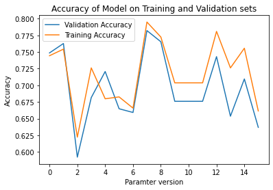

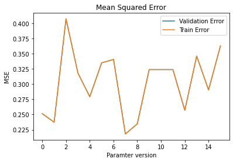

```python
Params_feats = []

for i in range (len(perceptron_acc)):
    Params_feats.append(i)

plt.figure()
plt.plot(Params_feats, validation_acc, label = 'Validation Accuracy')
plt.plot(Params_feats, training_acc, label = 'Training Accuracy')
plt.xlabel('Paramter version')
plt.ylabel('Accuracy')
plt.title('Accuracy of Model on Training and Validation sets')
plt.legend(loc='best')

plt.figure()
plt.plot(Params_feats, mse_valid, label = 'Validation Error')
plt.plot(Params_feats, mse_valid, label = 'Train Error')
plt.xlabel('Paramter version')
plt.ylabel('MSE')
plt.title('Mean Squared Error')
plt.legend(loc='best')
```

**Analysis:**

## 6.6 Linear SVC:

This support vector classifier uses a linear kernel function to provide an outcome analysis and has good performce with large datasets as it automatically implements penalty normalization. A drawback of this method is that the linear function is not adjustable and thus specific model fitting becomes challenging. Learn more

```python
linear_svc_acc = []
Y_pred_linear_svc = []
validation_acc = []
training_acc = []
mse_valid = []
mse_train = []

for i in range(len(featureEngineering)):
    if type(featureEngineering[i]) != np.ndarray:
        feature = featureEngineering[i].copy(deep=True)
        X = feature.drop(columns= ['Survived'])
        y = feature['Survived']
    test_data = testFeatureEngineering[i].copy(deep=True)

    # validation
    X_train,X_test,y_train,y_test=train_test_split(X,y,test_size=0.2,random_state=1)
    linear_svc = LinearSVC()
    linear_svc.fit(X_train, y_train)
    Y_pred = linear_svc.predict(X_test)

    # accuracy
    print('Accuracy for fe' + str(i))
    a1 = metrics.accuracy_score(y_train, linear_svc.predict(X_train))
    print("Train set Accuracy: ", a1)
    a2 = metrics.accuracy_score(y_test, Y_pred)
    print("Test set Accuracy: ", a2)
    a3 = f1_score(y_test, Y_pred, average='weighted')
    print('F1 Score:', a3)
    a4 = cross_val_score(linear_svc,X_train,y_train,cv=5)
    a4 = a4.mean()
    print('Cross-val mean: ', a4)
    mean_acc = round(((a1 + a2 + a3 + a4)/4) * 100, 2)
    linear_svc_acc.append(mean_acc)
    print('linear_svc has a mean accuracy score of: ' + str(mean_acc) + '%\n')
    validationAccuracy.append(mean_acc)

    validation_acc.append(a2)
    training_acc.append(a1)
    mse_valid.append(mean_squared_error(y_test, Y_pred))
    mse_train.append(mean_squared_error(y_train, linear_svc.predict(X_train)))

    # actual
    linear_svc.fit(X, y)
    cols = list(test_data.columns.values)
    for col in cols:
        test_data[col].fillna(test_data[col].mean(), inplace=True)
    Y_pred = linear_svc.predict(test_data)
    Y_pred_linear_svc.append(Y_pred)

linear_svc_acc_max = max(linear_svc_acc)

for i in range (len(linear_svc_acc)):
    if linear_svc_acc[i] == linear_svc_acc_max :
        linear_svc_acc_max_index = i

print('The best accuracy score was: ' + str(linear_svc_acc_max))
```

```
Accuracy for fe0
Train set Accuracy:  0.7598314606741573
Test set Accuracy:  0.7430167597765364
F1 Score: 0.7292138084283992
Cross-val mean:  0.7837683443317247
linear_svc has a mean accuracy score of: 75.4%

Accuracy for fe1
Train set Accuracy:  0.7911931818181818
Test set Accuracy:  0.7853107344632768
F1 Score: 0.783189638915918
Cross-val mean:  0.7841337386018237
linear_svc has a mean accuracy score of: 78.6%

Accuracy for fe2
Train set Accuracy:  0.75
Test set Accuracy:  0.7597765363128491
F1 Score: 0.7618215069971991
Cross-val mean:  0.7402245641682261
linear_svc has a mean accuracy score of: 75.3%

Accuracy for fe3
Train set Accuracy:  0.8047752808988764
Test set Accuracy:  0.7821229050279329
F1 Score: 0.7777690035143725
Cross-val mean:  0.8006796020880529
linear_svc has a mean accuracy score of: 79.13%

Accuracy for fe4
Train set Accuracy:  0.7991573033707865
Test set Accuracy:  0.7821229050279329
F1 Score: 0.7813575537104185
Cross-val mean:  0.7683246331133655
linear_svc has a mean accuracy score of: 78.27%

Accuracy for fe5
Train set Accuracy:  0.7823033707865169
Test set Accuracy:  0.7877094972067039
F1 Score: 0.7890609773619962
Cross-val mean:  0.7303752585442727
```

[output cut: 58 more lines]

```
Accuracy for fe14
Train set Accuracy:  0.7626404494382022
Test set Accuracy:  0.7094972067039106
F1 Score: 0.6854784290061576
Cross-val mean:  0.6446469023933812
linear_svc has a mean accuracy score of: 70.06%

Accuracy for fe15
Train set Accuracy:  0.6966292134831461
Test set Accuracy:  0.7262569832402235
F1 Score: 0.7024940485687325
Cross-val mean:  0.7612725302866148
linear_svc has a mean accuracy score of: 72.17%

The best accuracy score was: 80.0
```

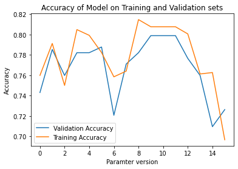

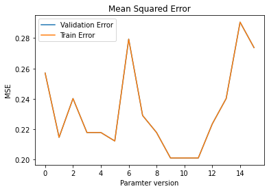

```python
Params_feats = []

for i in range (len(linear_svc_acc)):
    Params_feats.append(i)

plt.figure()
plt.plot(Params_feats, validation_acc, label = 'Validation Accuracy')
plt.plot(Params_feats, training_acc, label = 'Training Accuracy')
plt.xlabel('Paramter version')
plt.ylabel('Accuracy')
plt.title('Accuracy of Model on Training and Validation sets')
plt.legend(loc='best')

plt.figure()
plt.plot(Params_feats, mse_valid, label = 'Validation Error')
plt.plot(Params_feats, mse_valid, label = 'Train Error')
plt.xlabel('Paramter version')
plt.ylabel('MSE')
plt.title('Mean Squared Error')
plt.legend(loc='best')
```

**Analysis:**

## 6.7 Stochastic gradient descent:

This optimization algorithm is a powerful tool in minimizing the loss function, thus greatly improving prediction accuracy. It occassionally results in an inaccuracte result due to local maxima and minima, however the results are still accurate to an extend, even when this occurs. In a classification specific problem, this method minimizes cross-entropy functions, however, this depends on the required predictions to be made. The goal is to minimize the prediction error by adjustion the model parameters to find the best fit. [Learn more](https://realpython.com/gradient-descent-algorithm-python/)

```python
sgd_acc = []
Y_pred_sgd = []
validation_acc = []
training_acc = []
mse_valid = []
mse_train = []

for i in range(len(featureEngineering)):
    if type(featureEngineering[i]) != np.ndarray:
        feature = featureEngineering[i].copy(deep=True)
        X = feature.drop(columns= ['Survived'])
        y = feature['Survived']
    test_data = testFeatureEngineering[i].copy(deep=True)

    # validation
    X_train,X_test,y_train,y_test=train_test_split(X,y,test_size=0.2,random_state=1)
    sgd = SGDClassifier()
    sgd.fit(X_train, y_train)
    Y_pred = sgd.predict(X_test)

    # accuracy
    print('Accuracy for fe' + str(i))
    a1 = metrics.accuracy_score(y_train, sgd.predict(X_train))
    print("Train set Accuracy: ", a1)
    a2 = metrics.accuracy_score(y_test, Y_pred)
    print("Test set Accuracy: ", a2)
    a3 = f1_score(y_test, Y_pred, average='weighted')
    print('F1 Score:', a3)
    a4 = cross_val_score(sgd,X_train,y_train,cv=5)
    a4 = a4.mean()
    print('Cross-val mean: ', a4)
    mean_acc = round(((a1 + a2 + a3 + a4)/4) * 100, 2)
    sgd_acc.append(mean_acc)
    print('sgd has a mean accuracy score of: ' + str(mean_acc) + '%\n')
    validationAccuracy.append(mean_acc)

    validation_acc.append(a2)
    training_acc.append(a1)
    mse_valid.append(mean_squared_error(y_test, Y_pred))
    mse_train.append(mean_squared_error(y_train, sgd.predict(X_train)))

    # actual
    sgd.fit(X, y)
    cols = list(test_data.columns.values)
    for col in cols:
        test_data[col].fillna(test_data[col].mean(), inplace=True)
    Y_pred = sgd.predict(test_data)
    Y_pred_sgd.append(Y_pred)

sgd_acc_max = max(sgd_acc)

for i in range (len(sgd_acc)):
    if sgd_acc[i] == sgd_acc_max :
        sgd_acc_max_index = i

print('The best accuracy score was: ' + str(sgd_acc_max))
```

```
Accuracy for fe0
Train set Accuracy:  0.7542134831460674
Test set Accuracy:  0.7653631284916201
F1 Score: 0.7673332486879972
Cross-val mean:  0.6655963754555304
sgd has a mean accuracy score of: 73.81%

Accuracy for fe1
Train set Accuracy:  0.6605113636363636
Test set Accuracy:  0.6949152542372882
F1 Score: 0.6895694175496616
Cross-val mean:  0.6874062816616008
sgd has a mean accuracy score of: 68.31%

Accuracy for fe2
Train set Accuracy:  0.40870786516853935
Test set Accuracy:  0.441340782122905
F1 Score: 0.31340508979197695
Cross-val mean:  0.6713188220230475
sgd has a mean accuracy score of: 45.87%

Accuracy for fe3
Train set Accuracy:  0.800561797752809
Test set Accuracy:  0.7597765363128491
F1 Score: 0.7549760807978978
Cross-val mean:  0.7360386092780459
sgd has a mean accuracy score of: 76.28%

Accuracy for fe4
Train set Accuracy:  0.7851123595505618
Test set Accuracy:  0.7318435754189944
F1 Score: 0.7234819042992471
Cross-val mean:  0.7122131389737024
sgd has a mean accuracy score of: 73.82%

Accuracy for fe5
Train set Accuracy:  0.6446629213483146
Test set Accuracy:  0.6256983240223464
F1 Score: 0.5194318144186716
Cross-val mean:  0.6107455924357332
```

[output cut: 58 more lines]

```
Accuracy for fe14
Train set Accuracy:  0.7612359550561798
Test set Accuracy:  0.7206703910614525
F1 Score: 0.7038238171890288
Cross-val mean:  0.6585344233231558
sgd has a mean accuracy score of: 71.11%

Accuracy for fe15
Train set Accuracy:  0.7514044943820225
Test set Accuracy:  0.7262569832402235
F1 Score: 0.7281361661933496
Cross-val mean:  0.636225746084901
sgd has a mean accuracy score of: 71.05%

The best accuracy score was: 79.3
```

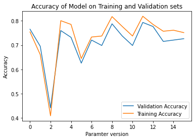

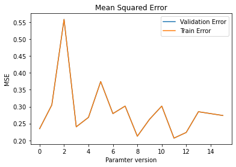

```python
Params_feats = []

for i in range (len(sgd_acc)):
    Params_feats.append(i)

plt.figure()
plt.plot(Params_feats, validation_acc, label = 'Validation Accuracy')
plt.plot(Params_feats, training_acc, label = 'Training Accuracy')
plt.xlabel('Paramter version')
plt.ylabel('Accuracy')
plt.title('Accuracy of Model on Training and Validation sets')
plt.legend(loc='best')

plt.figure()
plt.plot(Params_feats, mse_valid, label = 'Validation Error')
plt.plot(Params_feats, mse_valid, label = 'Train Error')
plt.xlabel('Paramter version')
plt.ylabel('MSE')
plt.title('Mean Squared Error')
plt.legend(loc='best')
```

**Analysis:**

## 6.8 Decision Tree:

A decision tree is a flow-chart like structure that depends on the features present in the dataset. A decison tree is based on the features in a datset and follow several path to ultimately reach the target variable. In this case the target variable is to determine if a passenger died or not. Decision trees can either be a classification or regression tree. In this problem we want to classify if a passenger died or not. In developing a tree we decide which features to include and exclude in order to split and move along a branch of the tree. [Learn more here] (https://towardsdatascience.com/decision-trees-in-machine-learning-641b9c4e8052)

```python
decision_tree_acc = []
Y_pred_decision_tree = []
validation_acc = []
training_acc = []
mse_valid = []
mse_train = []

for i in range(len(featureEngineering)):
    if type(featureEngineering[i]) != np.ndarray:
        feature = featureEngineering[i].copy(deep=True)
        X = feature.drop(columns= ['Survived'])
        y = feature['Survived']
    test_data = testFeatureEngineering[i].copy(deep=True)

    # validation
    X_train,X_test,y_train,y_test=train_test_split(X,y,test_size=0.2,random_state=1)
    decision_tree = DecisionTreeClassifier()
    decision_tree.fit(X_train, y_train)
    Y_pred = decision_tree.predict(X_test)

    # accuracy
    print('Accuracy for fe' + str(i))
    a1 = metrics.accuracy_score(y_train, decision_tree.predict(X_train))
    print("Train set Accuracy: ", a1)
    a2 = metrics.accuracy_score(y_test, Y_pred)
    print("Test set Accuracy: ", a2)
    a3 = f1_score(y_test, Y_pred, average='weighted')
    print('F1 Score:', a3)
    a4 = cross_val_score(decision_tree,X_train,y_train,cv=5)
    a4 = a4.mean()
    print('Cross-val mean: ', a4)
    mean_acc = round(((a1 + a2 + a3 + a4)/4) * 100, 2)
    decision_tree_acc.append(mean_acc)
    print('decision_tree has a mean accuracy score of: ' + str(mean_acc) + '%\n')
    validationAccuracy.append(mean_acc)

    validation_acc.append(a2)
    training_acc.append(a1)
    mse_valid.append(mean_squared_error(y_test, Y_pred))
    mse_train.append(mean_squared_error(y_train, decision_tree.predict(X_train)))

    # actual
    decision_tree.fit(X, y)
    cols = list(test_data.columns.values)
    for col in cols:
        test_data[col].fillna(test_data[col].mean(), inplace=True)
    Y_pred = decision_tree.predict(test_data)
    Y_pred_decision_tree.append(Y_pred)

decision_tree_acc_max = max(decision_tree_acc)

for i in range (len(decision_tree_acc)):
    if decision_tree_acc[i] == decision_tree_acc_max :
        decision_tree_acc_max_index = i

print('The best accuracy score was: ' + str(decision_tree_acc_max))
```

```
Accuracy for fe0
Train set Accuracy:  0.9311797752808989
Test set Accuracy:  0.7597765363128491
F1 Score: 0.7516863845549017
Cross-val mean:  0.7894316950654978
decision_tree has a mean accuracy score of: 80.8%

Accuracy for fe1
Train set Accuracy:  0.9289772727272727
Test set Accuracy:  0.7853107344632768
F1 Score: 0.7825017968103206
Cross-val mean:  0.8025835866261397
decision_tree has a mean accuracy score of: 82.48%

Accuracy for fe2
Train set Accuracy:  0.9283707865168539
Test set Accuracy:  0.7932960893854749
F1 Score: 0.7852479439902174
Cross-val mean:  0.7936176499556782
decision_tree has a mean accuracy score of: 82.51%

Accuracy for fe3
Train set Accuracy:  0.8637640449438202
Test set Accuracy:  0.7541899441340782
F1 Score: 0.7425107222521464
Cross-val mean:  0.8104501132670148
decision_tree has a mean accuracy score of: 79.27%

Accuracy for fe4
Train set Accuracy:  0.9382022471910112
Test set Accuracy:  0.7541899441340782
F1 Score: 0.7476880857063156
Cross-val mean:  0.7894218457598738
decision_tree has a mean accuracy score of: 80.74%

Accuracy for fe5
Train set Accuracy:  0.9873595505617978
Test set Accuracy:  0.7821229050279329
F1 Score: 0.7777690035143725
Cross-val mean:  0.758475327489412
```

[output cut: 58 more lines]

```
Accuracy for fe14
Train set Accuracy:  0.9887640449438202
Test set Accuracy:  0.7877094972067039
F1 Score: 0.7860818439415129
Cross-val mean:  0.7682655372796218
decision_tree has a mean accuracy score of: 83.27%

Accuracy for fe15
Train set Accuracy:  0.9873595505617978
Test set Accuracy:  0.7541899441340782
F1 Score: 0.7487681481847694
Cross-val mean:  0.7669063331035162
decision_tree has a mean accuracy score of: 81.43%

The best accuracy score was: 83.27
```

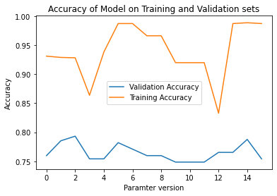

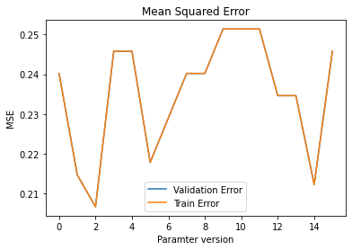

```python
Params_feats = []

for i in range (len(decision_tree_acc)):
    Params_feats.append(i)

plt.figure()
plt.plot(Params_feats, validation_acc, label = 'Validation Accuracy')
plt.plot(Params_feats, training_acc, label = 'Training Accuracy')
plt.xlabel('Paramter version')
plt.ylabel('Accuracy')
plt.title('Accuracy of Model on Training and Validation sets')
plt.legend(loc='best')

plt.figure()
plt.plot(Params_feats, mse_valid, label = 'Validation Error')
plt.plot(Params_feats, mse_valid, label = 'Train Error')
plt.xlabel('Paramter version')
plt.ylabel('MSE')
plt.title('Mean Squared Error')
plt.legend(loc='best')
```

**Analysis:**

## 6.9 Random Forest:

Random Forest classifiers consist of a decision tree. A decision tree can either be a classification or regression tree. Our decision variable is categorical and therefore the classfier is applied to the data. The random forest model consist of several decsion trees that build on each other and is related to bootstrap samples. Bootstrap samples refers to smaller samples that are drwan from the original data. [Learn more here](https://www.sciencedirect.com/topics/computer-science/random-forest-classifier) and here(https://www.sciencedirect.com/topics/computer-science/random-forest-classifier)

```python
random_forest_acc = []
Y_pred_random_forest = []
validation_acc = []
training_acc = []
mse_valid = []
mse_train = []

for i in range(len(featureEngineering)):
    if type(featureEngineering[i]) != np.ndarray:
        feature = featureEngineering[i].copy(deep=True)
        X = feature.drop(columns= ['Survived'])
        y = feature['Survived']
    test_data = testFeatureEngineering[i].copy(deep=True)

    # validation
    X_train,X_test,y_train,y_test=train_test_split(X,y,test_size=0.2,random_state=1)
    random_forest = RandomForestClassifier(random_state = 1)
    random_forest.fit(X_train, y_train)
    Y_pred = random_forest.predict(X_test)

    # accuracy
    print('Accuracy for fe' + str(i))
    a1 = metrics.accuracy_score(y_train, random_forest.predict(X_train))
    print("Train set Accuracy: ", a1)
    a2 = metrics.accuracy_score(y_test, Y_pred)
    print("Test set Accuracy: ", a2)
    a3 = f1_score(y_test, Y_pred, average='weighted')
    print('F1 Score:', a3)
    a4 = cross_val_score(random_forest,X_train,y_train,cv=5)
    a4 = a4.mean()
    print('Cross-val mean: ', a4)
    mean_acc = round(((a1 + a2 + a3 + a4)/4) * 100, 2)
    random_forest_acc.append(mean_acc)
    print('random_forest has a mean accuracy score of: ' + str(mean_acc) + '%\n')
    validationAccuracy.append(mean_acc)

    validation_acc.append(a2)
    training_acc.append(a1)
    mse_valid.append(mean_squared_error(y_test, Y_pred))
    mse_train.append(mean_squared_error(y_train, random_forest.predict(X_train)))

    # actual
    random_forest.fit(X, y)
    cols = list(test_data.columns.values)
    for col in cols:
        test_data[col].fillna(test_data[col].mean(), inplace=True)
    Y_pred = random_forest.predict(test_data)
    Y_pred_random_forest.append(Y_pred)

random_forest_acc_max = max(random_forest_acc)

for i in range (len(random_forest_acc)):
    if random_forest_acc[i] == random_forest_acc_max :
        random_forest_acc_max_index = i

print('The best accuracy score was: ' + str(random_forest_acc_max))
```

```
Accuracy for fe0
Train set Accuracy:  0.9311797752808989
Test set Accuracy:  0.7597765363128491
F1 Score: 0.7539601831550072
Cross-val mean:  0.8020388062641584
random_forest has a mean accuracy score of: 81.17%

Accuracy for fe1
Train set Accuracy:  0.9289772727272727
Test set Accuracy:  0.807909604519774
F1 Score: 0.8065696170413377
Cross-val mean:  0.7770111448834853
random_forest has a mean accuracy score of: 83.01%

Accuracy for fe2
Train set Accuracy:  0.9283707865168539
Test set Accuracy:  0.7821229050279329
F1 Score: 0.7758538034157243
Cross-val mean:  0.8104599625726386
random_forest has a mean accuracy score of: 82.42%

Accuracy for fe3
Train set Accuracy:  0.8637640449438202
Test set Accuracy:  0.7262569832402235
F1 Score: 0.7183804196761663
Cross-val mean:  0.796395154141633
random_forest has a mean accuracy score of: 77.62%

Accuracy for fe4
Train set Accuracy:  0.9382022471910112
Test set Accuracy:  0.7821229050279329
F1 Score: 0.7758538034157243
Cross-val mean:  0.8090022653402935
random_forest has a mean accuracy score of: 82.63%

Accuracy for fe5
Train set Accuracy:  0.9873595505617978
Test set Accuracy:  0.7988826815642458
F1 Score: 0.7944466666966297
Cross-val mean:  0.820309268196592
```

[output cut: 58 more lines]

```
Accuracy for fe14
Train set Accuracy:  0.9887640449438202
Test set Accuracy:  0.770949720670391
F1 Score: 0.7672672647595613
Cross-val mean:  0.8287402738106963
random_forest has a mean accuracy score of: 83.89%

Accuracy for fe15
Train set Accuracy:  0.9873595505617978
Test set Accuracy:  0.7653631284916201
F1 Score: 0.7601877778127346
Cross-val mean:  0.8132374667585935
random_forest has a mean accuracy score of: 83.15%

The best accuracy score was: 85.05
```

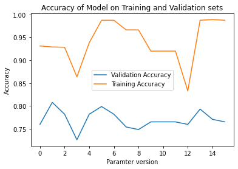

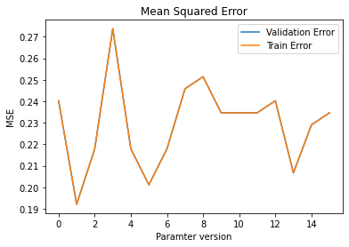

```python
Params_feats = []

for i in range (len(random_forest_acc)):
    Params_feats.append(i)

plt.figure()
plt.plot(Params_feats, validation_acc, label = 'Validation Accuracy')
plt.plot(Params_feats, training_acc, label = 'Training Accuracy')
plt.xlabel('Paramter version')
plt.ylabel('Accuracy')
plt.title('Accuracy of Model on Training and Validation sets')
plt.legend(loc='best')

plt.figure()
plt.plot(Params_feats, mse_valid, label = 'Validation Error')
plt.plot(Params_feats, mse_valid, label = 'Train Error')
plt.xlabel('Paramter version')
plt.ylabel('MSE')
plt.title('Mean Squared Error')
plt.legend(loc='best')
```

**Analysis:**

## 6.10 Model Accuracy

Compare all models to see accuracy on training data:

- Logical Regression
- Support Vector Machines
- KNN
- Gaussian Naive Bayes
- Perceptron
- Linear SVC
- Stochastic Gradient Descent
- Decision Tree
- Random Forest

```python
temp_models = pd.DataFrame({'Model': ['Support Vector Machines', 'KNN', 'Logistic Regression',
                                'Random Forest', 'Naive Bayes', 'Perceptron', 'Stochastic Gradient Decent',
                                'Linear SVC', 'Decision Tree'],
                            'Best_Score' : [svc_acc_max, knn_acc_max, logreg_acc_max, random_forest_acc_max, gaussian_acc_max, perceptron_acc_max,
                                sgd_acc_max, linear_svc_acc_max, decision_tree_acc_max],
                            'Best_Score_Index' : [svc_acc_max_index, knn_acc_max_index, logreg_acc_max_index, random_forest_acc_max_index, gaussian_acc_max_index, perceptron_acc_max_index,
                                sgd_acc_max_index, linear_svc_acc_max_index, decision_tree_acc_max_index],
                            'FE0_Score': [svc_acc[0], knn_acc[0], logreg_acc[0], random_forest_acc[0], gaussian_acc[0], perceptron_acc[0],
                                sgd_acc[0], linear_svc_acc[0], decision_tree_acc[0]],
                            'FE1_Score': [svc_acc[1], knn_acc[1], logreg_acc[1], random_forest_acc[1], gaussian_acc[1], perceptron_acc[1],
                                sgd_acc[1], linear_svc_acc[1], decision_tree_acc[1]],
                            'FE2_Score': [svc_acc[2], knn_acc[2], logreg_acc[2], random_forest_acc[2], gaussian_acc[2], perceptron_acc[2],
                                sgd_acc[2], linear_svc_acc[2], decision_tree_acc[2]],
                            'FE3_Score': [svc_acc[3], knn_acc[3], logreg_acc[3], random_forest_acc[3], gaussian_acc[3], perceptron_acc[3],
                                sgd_acc[3], linear_svc_acc[3], decision_tree_acc[3]],
                            'FE4_Score': [svc_acc[4], knn_acc[4], logreg_acc[4], random_forest_acc[4], gaussian_acc[4], perceptron_acc[4],
                                sgd_acc[4], linear_svc_acc[4], decision_tree_acc[4]],
                            'FE5_Score': [svc_acc[5], knn_acc[5], logreg_acc[5], random_forest_acc[5], gaussian_acc[5], perceptron_acc[5],
                                sgd_acc[5], linear_svc_acc[5], decision_tree_acc[5]],
                            'FE6_Score': [svc_acc[6], knn_acc[6], logreg_acc[6], random_forest_acc[6], gaussian_acc[6], perceptron_acc[6],
                                sgd_acc[6], linear_svc_acc[6], decision_tree_acc[6]],
                            'FE7_Score': [svc_acc[7], knn_acc[7], logreg_acc[7], random_forest_acc[7], gaussian_acc[7], perceptron_acc[7],
                                sgd_acc[7], linear_svc_acc[7], decision_tree_acc[7]],
                            'FE8_Score': [svc_acc[8], knn_acc[8], logreg_acc[8], random_forest_acc[8], gaussian_acc[8], perceptron_acc[8],
                                sgd_acc[8], linear_svc_acc[8], decision_tree_acc[8]],
                            'FE9_Score': [svc_acc[9], knn_acc[9], logreg_acc[9], random_forest_acc[9], gaussian_acc[9], perceptron_acc[9],
                                sgd_acc[9], linear_svc_acc[9], decision_tree_acc[9]],
                            'FE10_Score': [svc_acc[10], knn_acc[10], logreg_acc[10], random_forest_acc[10], gaussian_acc[10], perceptron_acc[10],
                                sgd_acc[10], linear_svc_acc[10], decision_tree_acc[10]],
                            'FE11_Score': [svc_acc[11], knn_acc[11], logreg_acc[11], random_forest_acc[11], gaussian_acc[11], perceptron_acc[11],
                                sgd_acc[11], linear_svc_acc[11], decision_tree_acc[11]],
                            'FE12_Score': [svc_acc[12], knn_acc[12], logreg_acc[12], random_forest_acc[12], gaussian_acc[12], perceptron_acc[12],
                                sgd_acc[12], linear_svc_acc[12], decision_tree_acc[12]],
                            'FE13_Score': [svc_acc[13], knn_acc[13], logreg_acc[13], random_forest_acc[13], gaussian_acc[13], perceptron_acc[13],
                                sgd_acc[13], linear_svc_acc[13], decision_tree_acc[13]],
                            'FE14_Score': [svc_acc[14], knn_acc[14], logreg_acc[14], random_forest_acc[14], gaussian_acc[14], perceptron_acc[14],
                                sgd_acc[14], linear_svc_acc[14], decision_tree_acc[14]],
                            'FE15_Score': [svc_acc[15], knn_acc[15], logreg_acc[15], random_forest_acc[15], gaussian_acc[15], perceptron_acc[15],
                                sgd_acc[15], linear_svc_acc[15], decision_tree_acc[15]]
                           })

temp_models.sort_values(by = 'Best_Score', ascending = False, ignore_index = True)
```

|  | Model | Best_Score | Best_Score_Index | FE0_Score | FE1_Score | FE2_Score | FE3_Score | FE4_Score | FE5_Score | FE6_Score | FE7_Score | FE8_Score | FE9_Score | FE10_Score | FE11_Score | FE12_Score | FE13_Score | FE14_Score | FE15_Score |
| --- | --- | --- | --- | --- | --- | --- | --- | --- | --- | --- | --- | --- | --- | --- | --- | --- | --- | --- | --- |
| 0 | Random Forest | 85.05 | 13 | 81.17 | 83.01 | 82.42 | 77.62 | 82.63 | 85.02 | 84.06 | 82.17 | 81.65 | 82.24 | 82.24 | 82.24 | 78.65 | 85.05 | 83.89 | 83.15 |
| 1 | Decision Tree | 83.27 | 14 | 80.80 | 82.48 | 82.51 | 79.27 | 80.74 | 82.64 | 82.35 | 82.03 | 81.84 | 80.75 | 80.63 | 80.70 | 78.86 | 81.70 | 83.27 | 81.43 |
| 2 | Support Vector Machines | 80.77 | 11 | 64.15 | 66.34 | 64.50 | 79.65 | 64.50 | 65.81 | 65.81 | 65.91 | 65.51 | 80.77 | 80.77 | 80.77 | 79.48 | 64.91 | 65.49 | 64.92 |
| 3 | Logistic Regression | 80.27 | 6 | 79.15 | 78.94 | 80.09 | 79.12 | 78.93 | 79.93 | 80.27 | 79.85 | 80.10 | 79.26 | 79.26 | 79.26 | 78.16 | 79.23 | 78.99 | 76.30 |
| 4 | Linear SVC | 80.00 | 11 | 75.40 | 78.60 | 75.30 | 79.13 | 78.27 | 77.24 | 72.25 | 77.15 | 77.77 | 80.00 | 80.00 | 80.00 | 78.62 | 75.22 | 70.06 | 72.17 |
| 5 | Naive Bayes | 79.39 | 2 | 77.99 | 77.58 | 79.39 | 76.47 | 73.72 | 78.25 | 78.25 | 74.15 | 74.22 | 74.25 | 74.25 | 74.25 | 77.59 | 76.89 | 77.16 | 76.75 |
| 6 | KNN | 79.35 | 11 | 77.19 | 77.53 | 77.50 | 78.07 | 75.47 | 71.71 | 72.82 | 76.98 | 77.83 | 79.35 | 79.35 | 79.35 | 75.75 | 71.99 | 76.10 | 70.81 |
| 7 | Stochastic Gradient Decent | 79.30 | 11 | 73.81 | 68.31 | 45.87 | 76.28 | 73.82 | 60.01 | 71.14 | 68.37 | 76.73 | 74.75 | 72.59 | 79.30 | 77.61 | 72.41 | 71.11 | 71.05 |
| 8 | Perceptron | 74.62 | 12 | 72.98 | 73.05 | 58.64 | 67.37 | 70.55 | 64.89 | 65.99 | 74.12 | 73.17 | 65.38 | 65.38 | 65.38 | 74.62 | 65.85 | 72.43 | 64.58 |

**Analysis of model accuracy:**

The table above shows the accuracy of each model based on all combinations of parameters selected and sorts them in order of best performance. This allows for selection of models as well as the parameters to include for each model.

# 7 MODEL TUNING

```python
sets = [fe6, fe12, fe14]
sets_test = [fe6_test, fe12_test, fe14_test]
```

## 7.1 Cross Validation

Cross validation was implemented to verify the table from section 6.10 Model Accuracy.

### 7.1.1) K-fold cross validation

```python
# Create a list which contains classifiers

classifiers = []
classifiers.append(LogisticRegression())
classifiers.append(SVC())
classifiers.append(KNeighborsClassifier(n_neighbors = 5))
classifiers.append(GaussianNB())
classifiers.append(Perceptron())
classifiers.append(LinearSVC())
classifiers.append(SGDClassifier())
classifiers.append(DecisionTreeClassifier())
classifiers.append(RandomForestClassifier())
```

```python
# Create a list which contains cross validation results for each classifier

cv_results = []
for classifier in classifiers:
    cv_results.append(cross_val_score(classifier, X, y, scoring = 'accuracy', cv = 10))
```

### 7.1.2) Mean and standard deviation of cross validation

```python
cv_mean = []
cv_std = []
for cv_result in cv_results:
    cv_mean.append(cv_result.mean())
    cv_std.append(cv_result.std())
```

```python
cv_res = pd.DataFrame({'Cross Validation Mean': cv_mean, 'Cross Validation Std': cv_std, 'Algorithm': ['Logistic Regression', 'Support Vector Machines', 'KNN', 'Gausian Naive Bayes', 'Perceptron', 'Linear SVC', 'Stochastic Gradient Descent', 'Decision Tree', 'Random Forest']})
cv_res.sort_values(by = 'Cross Validation Mean', ascending = False, ignore_index = True)
```

|  | Cross Validation Mean | Cross Validation Std | Algorithm |
| --- | --- | --- | --- |
| 0 | 0.799201 | 0.047973 | Random Forest |
| 1 | 0.795743 | 0.039454 | Decision Tree |
| 2 | 0.777803 | 0.035278 | Logistic Regression |
| 3 | 0.776704 | 0.029892 | Gausian Naive Bayes |
| 4 | 0.749763 | 0.051982 | Linear SVC |
| 5 | 0.700212 | 0.095194 | Stochastic Gradient Descent |
| 6 | 0.677978 | 0.051539 | Support Vector Machines |
| 7 | 0.676841 | 0.035693 | KNN |
| 8 | 0.629600 | 0.085385 | Perceptron |

The high training accuracy is not realistic, especially when the model’s ability is to predict out-of-sample data. K-fold cross-validation comes into play as it is a method that uses a portion of our training set as a holdout set for testing purposes. In the above table, certain models’ accuracies had dropped in score from previous scores including ones like logistic regression. Mainly the top performance models will be used for model tuning.

## 7.2 Model Tuning

```python
models = pd.DataFrame({'Model': ['KNN', 'Logistic Regression',
                                'Random Forest'],
                      'Score': [knn_acc_max, logreg_acc_max, random_forest_acc_max]})

models.sort_values(by = 'Score', ascending = False, ignore_index = True)
```

|  | Model | Score |
| --- | --- | --- |
| 0 | Random Forest | 85.05 |
| 1 | Logistic Regression | 80.27 |
| 2 | KNN | 79.35 |

The selection was done based on performance, with some exeptions. Based on the information from section 7, we decided the following 3 models would be the most accutrate. Random Forest and Log Regression seem like 2 models which will work well with one another in ensembling. KNN was added for testing but was later removed from the ensembling section due to poor performance results.

```python
#simple performance reporting function
def clf_performance(classifier, model_name):
    print(model_name)
    print('Best Score: ' + str(classifier.best_score_))
    print('Best Parameters: ' + str(classifier.best_params_))
```

```
For Feature Engineering Set:  fe6

For Random Forest:
Fitting 5 folds for each of 288 candidates, totalling 1440 fits
Random Forest
Best Score: 0.833927562613772
Best Parameters: {'bootstrap': True, 'criterion': 'entropy', 'max_depth': 15, 'max_features': 'auto', 'min_samples_leaf': 2, 'min_samples_split': 2, 'n_estimators': 450}

For Logistic Regression:
Fitting 5 folds for each of 40 candidates, totalling 200 fits
Logistic Regression
Best Score: 0.7991023790094784
Best Parameters: {'C': 0.08858667904100823, 'max_iter': 2000, 'penalty': 'l2', 'solver': 'liblinear'}

For KNN:
Fitting 5 folds for each of 48 candidates, totalling 240 fits
KNN
Best Score: 0.7396648044692737
Best Parameters: {'algorithm': 'auto', 'n_neighbors': 5, 'p': 1, 'weights': 'distance'}

For Feature Engineering Set:  fe12

For Random Forest:
Fitting 5 folds for each of 288 candidates, totalling 1440 fits
Random Forest
Best Score: 0.7912748728893353
Best Parameters: {'bootstrap': True, 'criterion': 'gini', 'max_depth': 15, 'max_features': 'auto', 'min_samples_leaf': 2, 'min_samples_split': 2, 'n_estimators': 500}

For Logistic Regression:
Fitting 5 folds for each of 40 candidates, totalling 200 fits
Logistic Regression
Best Score: 0.7957190383528969
Best Parameters: {'C': 0.23357214690901212, 'max_iter': 2000, 'penalty': 'l2', 'solver': 'liblinear'}

For KNN:
Fitting 5 folds for each of 48 candidates, totalling 240 fits
KNN
Best Score: 0.7923921913250893
Best Parameters: {'algorithm': 'ball_tree', 'n_neighbors': 9, 'p': 1, 'weights': 'distance'}

For Feature Engineering Set:  fe14

For Random Forest:
Fitting 5 folds for each of 288 candidates, totalling 1440 fits
Random Forest
Best Score: 0.836137091205825
Best Parameters: {'bootstrap': True, 'criterion': 'gini', 'max_depth': 25, 'max_features': 'auto', 'min_samples_leaf': 2, 'min_samples_split': 2, 'n_estimators': 450}

For Logistic Regression:
Fitting 5 folds for each of 40 candidates, totalling 200 fits
Logistic Regression
Best Score: 0.7946079969870065
Best Parameters: {'C': 0.615848211066026, 'max_iter': 2000, 'penalty': 'l1', 'solver': 'liblinear'}

For KNN:
Fitting 5 folds for each of 48 candidates, totalling 240 fits
KNN
Best Score: 0.7688469022660221
Best Parameters: {'algorithm': 'auto', 'n_neighbors': 3, 'p': 1, 'weights': 'uniform'}
```

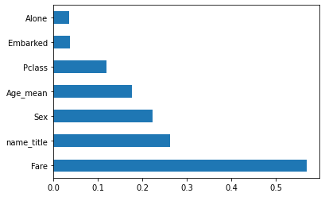

```python
best_clf_rf_list = []
best_clf_lr_list = []
best_clf_knn_list = []
names = ['fe6', 'fe12', 'fe14']

for i in range(len(sets)):
    dataFrame = sets[i].copy(deep=True)
    dataFrame_test = sets_test[i].copy(deep=True)
    X = dataFrame.drop(columns= ['Survived'])
    y = dataFrame['Survived']

    print('\nFor Feature Engineering Set: ', names[i])
    print('\nFor Random Forest: ')
    rf = RandomForestClassifier(random_state = 1)
    param_grid = {'n_estimators': [400,450,500,550],
                   'criterion':['gini','entropy'],
                   'bootstrap': [True],
                   'max_depth': [15, 20, 25],
                   'max_features': ['auto','sqrt', 10],
                   'min_samples_leaf': [2,3],
                   'min_samples_split': [2,3]}

    clf_rf = GridSearchCV(rf, param_grid = param_grid, cv = 5, verbose = True, n_jobs = -1)
    best_clf_rf = clf_rf.fit(X,y)
    best_clf_rf_list.append(best_clf_rf)
    clf_performance(best_clf_rf,'Random Forest')
    best_rf = best_clf_rf.best_estimator_.fit(X,y)
    feat_importances = pd.Series(best_rf.feature_importances_, index=X.columns)
    feat_importances.nlargest(20).plot(kind='barh')

    print('\nFor Logistic Regression: ')
    lr = LogisticRegression()
    param_grid = {'max_iter' : [2000],
                  'penalty' : ['l1', 'l2'],
                  'C' : np.logspace(-4, 4, 20),
                  'solver' : ['liblinear']}

    clf_lr = GridSearchCV(lr, param_grid = param_grid, cv = 5, verbose = True, n_jobs = -1)
    best_clf_lr = clf_lr.fit(X,y)
    best_clf_lr_list.append(best_clf_lr)
    clf_performance(best_clf_lr,'Logistic Regression')

    print('\nFor KNN: ')
    knn = KNeighborsClassifier()
    param_grid = {'n_neighbors' : [3,5,7,9],
                  'weights' : ['uniform', 'distance'],
                  'algorithm' : ['auto', 'ball_tree','kd_tree'],
                  'p' : [1,2]}
    clf_knn = GridSearchCV(knn, param_grid = param_grid, cv = 5, verbose = True, n_jobs = -1)
    best_clf_knn = clf_knn.fit(X,y)
    best_clf_knn_list.append(best_clf_knn)
    clf_performance(best_clf_knn,'KNN')
```

```python
models = pd.DataFrame({'Model': ['KNN', 'Logistic Regression', 'Random Forest'],
                        'Score': [knn_acc_max, logreg_acc_max, random_forest_acc_max],
                        #'Tuned Score': [round((best_clf_rf.best_score_)*100,2), round((best_clf_svc.best_score_)*100,2), round((best_clf_knn.best_score_)*100,2), round((best_clf_lr.best_score_)*100,2)]})
                        'Tuned Score for fe6': [round((best_clf_knn_list[0].best_score_)*100,2), round((best_clf_lr_list[0].best_score_)*100,2), round((best_clf_rf_list[0].best_score_)*100,2)],
                        'Tuned Score for fe12': [round((best_clf_knn_list[1].best_score_)*100,2), round((best_clf_lr_list[1].best_score_)*100,2), round((best_clf_rf_list[1].best_score_)*100,2)],
                        'Tuned Score for fe14': [round((best_clf_knn_list[2].best_score_)*100,2), round((best_clf_lr_list[2].best_score_)*100,2), round((best_clf_rf_list[2].best_score_)*100,2)]})

models.sort_values(by = 'Score', ascending = False, ignore_index = True)
```

|  | Model | Score | Tuned Score for fe6 | Tuned Score for fe12 | Tuned Score for fe14 |
| --- | --- | --- | --- | --- | --- |
| 0 | Random Forest | 85.05 | 83.39 | 79.13 | 83.61 |
| 1 | Logistic Regression | 80.27 | 79.91 | 79.57 | 79.46 |
| 2 | KNN | 79.35 | 73.97 | 79.24 | 76.88 |

## 7.3 Model Ensembling

#### (a) The Voting Classifier Ensembler

The classifiers have been well calibrating in the Model Tuning section, thus the soft voting method has been implemented as:

where wj is the weight that can be assigned to the jth classifier.

```python
voting_clf_soft = VotingClassifier(estimators = [('lr',best_clf_lr_list[1]),('rf',best_clf_rf_list[1])], voting = 'soft')
voting_clf_soft.fit(X, y)
y_hat_vc_soft =  voting_clf_soft.predict(dataFrame_test).astype(int)
```

```
Fitting 5 folds for each of 40 candidates, totalling 200 fits
Fitting 5 folds for each of 288 candidates, totalling 1440 fits
```

b) Ensembling using the **Bagging** Classifier for Feature Engineering 12.

Bagging is a generic ensemble approach. It works by applying comparable classifiers to tiny sections of the dataset and then taking the average of all predictions. The variance is reduced as a result of averaging. Unlike Voting Classifier, Bagging employs comparable classifiers.

```python
dataFrame = sets[1].copy(deep=True)
dataFrame_test = sets_test[1].copy(deep=True)
X = dataFrame.drop(columns= ['Survived'])
y = dataFrame['Survived']

# define the model
model = BaggingClassifier()
# fit the model on the whole dataset
model.fit(X, y)
```

```
BaggingClassifier()
```

```python
yhat_bagging = model.predict(dataFrame_test)
```

Ensembling using **Boost**

Boosting is an ensembling method that employs successive classifier learning. It is a gradual improvement of a flawed model. Boosting functions as follows:

First, a model is trained on the entire dataset. Now the model will correctly identify some occurrences while incorrectly identifying others. In the following iteration, the learner will pay greater attention to the incorrectly anticipated instances or assign them more weight. As a result, it will attempt to accurately forecast the incorrect occurrence. This iterative process is now ongoing, and additional classifiers are added to the model until the accuracy limit is attained. XGBoost is designed to improve large-scale boosted tree algorithms.

```python
# XGBoost for result improvement
XGB = XGBClassifier(random_state = 1)
XGB.fit(X, y)
prediction = XGB.predict(dataFrame_test)
```

[output not shown]

# 8 MODEL SUBMISSION

Using the prediction from the specific feature engineering that has the highest accuracy for each model

```python
final_data_RF = {'PassengerId': test_ids.values, 'Survived': Y_pred_random_forest[13]}
submission_RF = pd.DataFrame(data=final_data_RF)

final_data_VC = {'PassengerId': test_ids.values, 'Survived': y_hat_vc_soft}
submission_VC = pd.DataFrame(data=final_data_VC)

final_data_BG = {'PassengerId': test_ids.values, 'Survived': yhat_bagging}
submission_BG = pd.DataFrame(data=final_data_BG)

final_data_BOOST = {'PassengerId': test_ids.values, 'Survived': prediction}
submission_BOOST = pd.DataFrame(data=final_data_BOOST)
```

```python
submission_RF.to_csv('submission_random_forest.csv', index=False)
submission_VC.to_csv('submission_votingClassifier_logreg_rf.csv', index=False)
submission_BG.to_csv('subission_bagging.csv', index=False)
submission_BOOST.to_csv('subission_Booster.csv', index=False)
```

# 9 Summary of division of work

All members were assigned to segments of the entire project, some tasks were assigned to more than one member. Additionally, work was not done entirely individually and assitance was given whenever it was required.

- **Van Niekerk Ferreira:** I was assigned to the Feature Engineering section. My work entailed extracting and devloping new features in order to analyse the features in more detail. This allowed the extraction of more useful information that increased the effectivity of our model when applied to the test data. I was also assigned to the model building and tuning section in which I analysed validation and training errors as well as the accuracies. Some of the features and models did not increase the accuracy of the model when comapred with the kaggle scores and accuracy calcualtions. This enabled me and the group to make decisions on which models and features to include in our final submission.
- **Tristan Basel:** Assigned to the model building section, this portion included partial addition to model tuning, graphical interpretation of the data acquired and tabulating important features. My analysis indicated that some models perform better than others (with higher accuracy and performance). The best results could be extracted for use later in the model tuning segment of which only the top performing models where given focus (some of the hyper-paremeter selection was initially addressed by me). This also allowed for better ensembling of models.
- **Tristan Lilford:** Performed data anlysis in order to understand basic correlations and important data values with Tristan de Groot. Proceeded to do some feature engineering with a focus on finding an optimal combination using different feature additions. This trial and error process was attempted to try and find the greatest possible accuracy results. Lastly was involved and consulted with model tuning.
- **Tristan de Groot:** Executed light, categorical and numerical data analysis with Tristan Lilford to find correlations between given variables and survivability. The shape of the data and existance of outliers and missing values was investigated. Set out the structure of the notebook so that the notebook is readable, standardised and presentable. Performed Model Ensembling with Jesse Iyuke to improve the accuracy of our tuned models through combing models. Three methods were used for ensembling: Bagging, Boosting and Voting Classifier of which the Voting Classifier was the most successful.
- **Robin Jonker:** Acted as the team lead both delegating and controlling project development. As such I was involved in all sections providing both insight and direction to my fellow team members. Along with Data Analysis, I was heavily involved in fine tuning to achieve the greatest results, to do this I created methods to test all the different features within the models and found the different features' respective accuracies, as seen above we had 16 different approaches, so that they could be compared with one another as well as allowing the system to be easily scalable for more feature and model additions.
- **Jesse Iyuke:** Under feature engineering, I worked under cabin and fare features. This was to work with the unknown values for certain passengers and included the creation of new features extracted from these two features to analyse in further detail, which can improve efficiency for input to the models. I worked on Cross-validation to ensure accuracy is more realistic. Under model ensembling, I worked on mostly bagging and boosting classfiers and assisted in the voting classifier. What was observed was the voting classifier performed the best and so the other two classifiers were not chosen for the final submission. I was also involved in the starting process of model building, like the splitting of the training dataset and accuracy score, as well as model tuning, where I initially included grid search for the SVM model which in turn did not turn out to be as effective and so was ruled out.

# 10 Analysis of Submissions

Below is a summary of some of our submissions with the public score achieved and the method employed in the submission. The best score is highlighted in bold.

[output not shown]

### Log of Group Submissions

Below see some of the recent submissions made by our group on Kaggle, with the best score indicated in purple.

[figure not shown]

### Leaderboard Position

Below see the relative leaderboard position on Kaggle given our best submission from above.

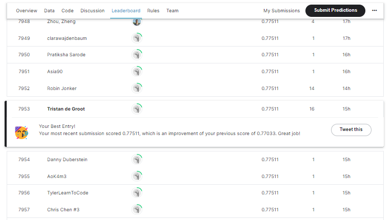

# 11 References

[1] Ken Jee: Titanic Project Example (https://www.kaggle.com/kenjee/titanic-project-example)

[2] Jason Chong: Titanic: Machine Learning from Disaster (https://github.com/chongjason914/kaggle-titanic)

[3] Nick Zhang: Ensemble for Titanic (https://www.kaggle.com/code/nickzylove/ensemble-for-titanic/notebook.)

[4] Minsuk-heo: Titanic: Machine Learning from Disaster (https://github.com/minsuk-heo/kaggle-titanic/blob/master/titanic-solution.ipynb.)